# Contributions from iNaturalist national sites

### Estimated parameters

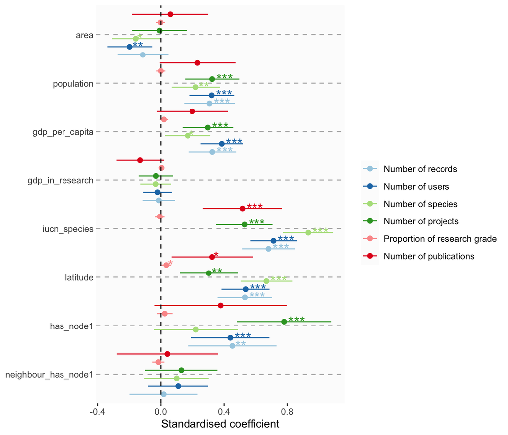

```r
pos <- position_dodge(1, orientation = 'y')

plot_lm_predictor_importance <- ggplot(tidy_models, aes(x=term, y=estimate, color=model, label=sig_stars)) +
    geom_jitter(size=2, position = pos) +
    scale_color_brewer(palette = "Paired", name = "") +
    geom_errorbar(aes(ymin=conf.low, ymax=conf.high), width=0, position = pos)+
    coord_flip() +
    geom_hline(yintercept = 0, linetype = "dashed") +
    labs(y = "Standardised coefficient", x = NULL) +
    ggpubr::theme_cleveland() +
    theme(panel.background = element_rect(fill = 'grey99')) +
    geom_text(aes(x = term, y = estimate, label = sig_stars, color = model),
              position = pos, size = 5, vjust = 0.5, hjust = -0.25,
              show.legend = FALSE)

plot_lm_predictor_importance
```

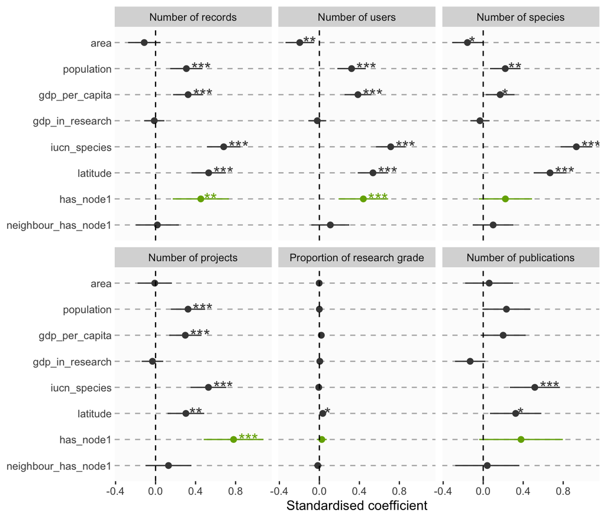

```r
plot_lm_predictor_importance_2 <-
  ggplot(tidy_models %>%
           mutate(is_has_node = ifelse(term=='has_node1', 'yes', 'no')),
       aes(x=term, y=estimate,
           color=is_has_node, label=sig_stars)) +
  geom_jitter(size=2, position = pos, show.legend=F) +
  scale_color_manual(values = c('#454545', '#74AC00')) +
  geom_errorbar(aes(ymin=conf.low, ymax=conf.high), width=0,
                position = pos, show.legend=F)+
  coord_flip() +
  geom_hline(yintercept = 0, linetype = "dashed") +
  labs(y = "Standardised coefficient", x = NULL) +
  ggpubr::theme_cleveland() +
  theme(panel.background = element_rect(fill = 'grey99')) +
  geom_text(aes(x = term, y = estimate,
                label = sig_stars, color = is_has_node),
            position = pos, size = 5,
            vjust = 0.5, hjust = -0.25,
            show.legend = FALSE) + facet_wrap(~model, scales = 'fixed')

plot_lm_predictor_importance_2
```

### Marginal effects

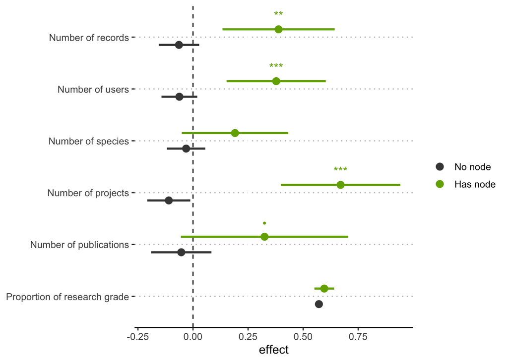

```r
effect_df <- function(model, model_name,
                      term = "has_node",
                      relabel = TRUE) {
  e <- effects::Effect(term, model, se = TRUE)
  df <- as.data.frame(e)
  if (relabel) {
    df[[term]] <- factor(df[[term]], levels = c("0","1"),
                         labels = c("No node","Has node"))
  }
  df$model <- model_name
  df
}

eff_list <- list(
  effect_df(lm_n_records, "Number of records"),
  effect_df(lm_n_users, "Number of users"),
  effect_df(lm_n_species, "Number of species"),
  effect_df(lm_n_projects, "Number of projects"),
  effect_df(lm_p_research_grade, "Proportion of research grade"),
  effect_df(lm_n_literature, "Number of publications"))

eff_all <- bind_rows(eff_list) %>%
  mutate(model = fct_relevel(model,
                             "Number of records",
                             "Number of users",
                             "Number of species",
                             "Number of projects",
                             "Proportion of research grade",
                             "Number of publications"))

stars_by_model <- list(
  "Number of records" = lm_n_records,
  "Number of users" = lm_n_users,
  "Number of species" = lm_n_species,
  "Number of projects" = lm_n_projects,
  "Proportion of research grade" = lm_p_research_grade,
  "Number of publications" = lm_n_literature) %>%
  imap_dfr(~ tidy(.x) %>%
             filter(grepl("^has_node", term)) %>%
             transmute(model = .y,
                       star = case_when(
                         p.value < 0.001 ~ "***",
                         p.value < 0.01  ~ "**",
                         p.value < 0.05  ~ "*",
                         p.value < 0.1   ~ "•",
                         TRUE            ~ "")))

# join onto effect dataframe and annotate "Has node"
eff_all_star <- eff_all %>%
  left_join(stars_by_model, by = "model") %>%
  mutate(star = replace_na(star, "")) %>%
  mutate(model = fct_relevel(
      model,
      "Proportion of research grade",
      "Number of publications",
      "Number of projects",
      "Number of species",
      "Number of users",
      "Number of records"))

pos <- position_dodge(width = 0.6)

plot_lm_main_effects <- ggplot(eff_all_star,
       aes(x = fit, y = model, color = has_node)) +
  geom_vline(xintercept = 0, linetype = 'dashed', lwd = 0.5) +
  geom_point(size = 3, position = pos) +
  geom_errorbar(aes(xmin = lower, xmax = upper),
                width = 0,linewidth = 1, position = pos,
                show.legend = FALSE) +
  geom_text(data = subset(eff_all_star,
                          has_node == "Has node" & star != ""),
            aes(label = star), position = pos,
            vjust = -2, show.legend = FALSE) +
  scale_color_manual(values = c('#454545', '#74AC00')) +
  labs(color = '', y = NULL, x = "effect") +
  ggpubr::theme_pubclean() +
  theme(legend.position = 'right',
        axis.line.x = element_line(size = 0.5))

plot_lm_main_effects
```

```r
eff_all_star %>% relocate(model) %>%  knitr::kable(digits = 3)
```

| model | has_node | fit | se | lower | upper | star |
| --- | --- | --- | --- | --- | --- | --- |
| Number of records | No node | -0.064 | 0.046 | -0.156 | 0.028 | ** |
| Number of records | Has node | 0.389 | 0.129 | 0.134 | 0.643 | ** |
| Number of users | No node | -0.062 | 0.041 | -0.143 | 0.019 | *** |
| Number of users | Has node | 0.378 | 0.114 | 0.152 | 0.603 | *** |
| Number of species | No node | -0.031 | 0.044 | -0.118 | 0.056 |  |
| Number of species | Has node | 0.191 | 0.122 | -0.051 | 0.432 |  |
| Number of projects | No node | -0.110 | 0.049 | -0.208 | -0.012 | *** |
| Number of projects | Has node | 0.670 | 0.137 | 0.399 | 0.941 | *** |
| Proportion of research grade | No node | 0.572 | 0.008 | 0.556 | 0.588 |  |
| Proportion of research grade | Has node | 0.596 | 0.023 | 0.551 | 0.641 |  |
| Number of publications | No node | -0.053 | 0.069 | -0.190 | 0.084 | • |
| Number of publications | Has node | 0.325 | 0.192 | -0.055 | 0.705 | • |

## Mixed-effects models

### Data

```r
data_temporal_records <- readRDS('data/archive/temporal_data_download/data_temporal_records.rds')
data_temporal_users <- readRDS('data/archive/temporal_data_download/data_temporal_users.rds')
data_temporal_species <- readRDS('data/archive/temporal_data_download/data_temporal_species.rds')
data_temporal_projects <- readRDS('data/archive/temporal_data_download/data_temporal_projects.rds')
data_temporal_prop_research_grade <- readRDS('data/archive/temporal_data_download/data_temporal_prop_research_grade.rds')
data_temporal_literature <- readRDS('data/archive/temporal_data_download/data_temporal_literature.rds')

data_mixed_effects <- data_variables %>%
  select(-c(region, flag, node_id, node_type, node_year, place_id)) %>%
  drop_na(area, population, gdp_per_capita, gdp_in_research, latitude, iucn_species) %>%
  filter(country_code != 'US')
```

### Number of records on iNaturalist per country, by year

```r
data_temporal_records <- readRDS('data/archive/temporal_data_download/data_temporal_records.rds')

data_temporal_records <- left_join(
  data_mixed_effects %>%
    select(-c(n_records, p_research_grade, n_users, n_species, n_projects, n_literature)),
  data_temporal_records %>% rename(n_records_years = n_records_inat)) %>%
  mutate(has_node = ifelse(!is.na(node_name), 1, 0))

data_temporal_lm <- data_temporal_records %>%
  mutate(area = scale(log10(area))[,1],
         population = scale(log10(population))[,1],
         gdp_per_capita = scale(log10(gdp_per_capita))[,1],
         latitude = scale(log10(abs(latitude)))[,1],
         iucn_species = scale(log10(iucn_species))[,1],
         has_node = as.factor(has_node),
         neighbour_has_node = as.factor(neighbour_has_node),
         n_records_years = scale(log10(n_records_years+1))[,1])

data_temporal_lm$year_c <- data_temporal_lm$year - mean(data_temporal_lm$year)
data_temporal_lm$has_node <- relevel(factor(data_temporal_lm$has_node), ref = "0")
data_temporal_lm$neighbour_has_node <- relevel(factor(data_temporal_lm$neighbour_has_node), ref = "0")
```

#### Time series plot

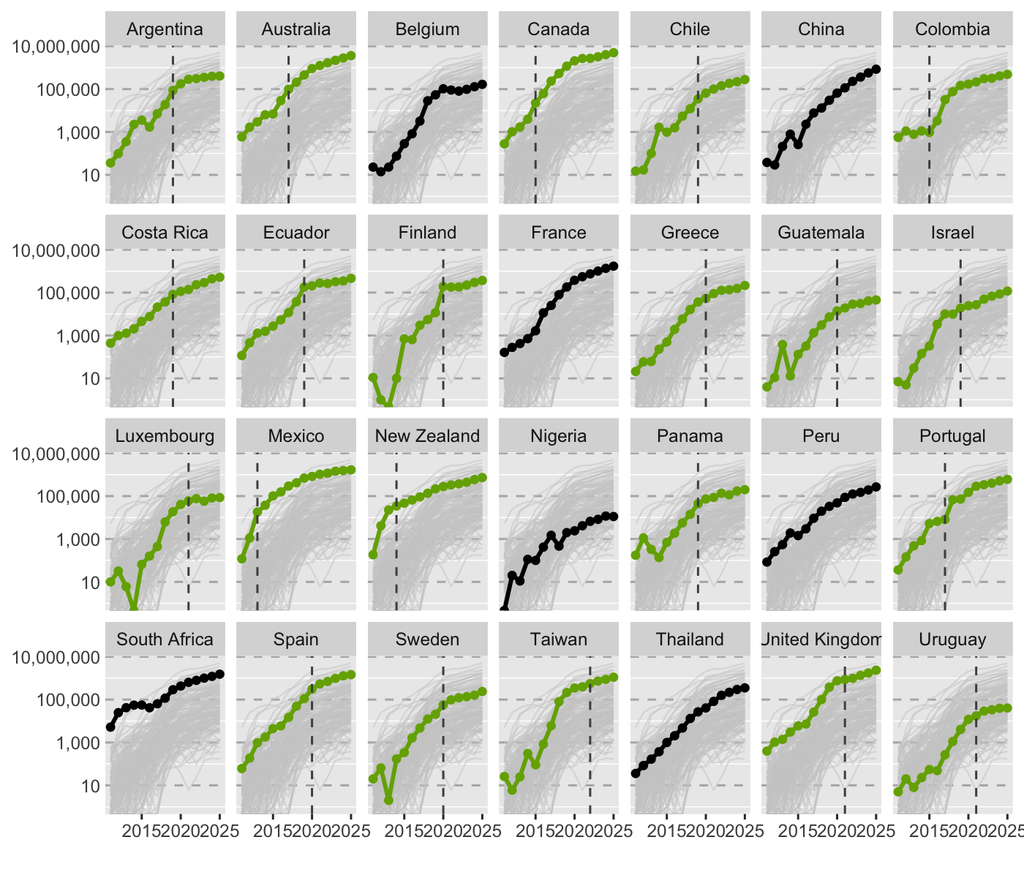

```r
data_temporal_records_plot <- left_join(
  data_variables %>%
    select(-c(n_records, p_research_grade, n_users, n_species, n_projects, n_literature)),
  data_temporal_records) %>%
  mutate(has_node = ifelse(!is.na(node_name), 1, 0))

# split data into highlighted and background
highlighted_nodes <- data_temporal_records_plot %>%
  filter(country_name %in% inat_network$node_country)

highlighted_others <- data_temporal_records_plot %>%
  filter(country_name %in% c('France', 'Peru', 'Thailand',
                             'Belgium', 'Bhtuan', 'China',
                             'South Africa', 'Nigeria'))

node_years <- highlighted_nodes %>%
  distinct(country_name, node_year)

temporal_records_plot_nodes_and_others <- bind_rows(highlighted_nodes, highlighted_others) %>%
  ggplot(aes(x = year, y = n_records_years,
             colour = factor(has_node))) +
  # grey background lines (all countries, in every facet)
  geom_line(
    data = data_temporal_records_plot %>% rename(country_name2 = country_name),
    aes(group = country_name2),
    colour = "grey80", linewidth = 0.4, alpha = 0.5
  ) +
  geom_line( linewidth = 1, show.legend = FALSE) +
  geom_point(size = 1.5, show.legend = FALSE) +
  scale_color_manual(values = c('black','#74AC00')) +
  geom_vline(
    data = node_years,
    aes(xintercept = node_year),
    linetype = "dashed",
    colour = "grey30",
    linewidth = 0.5
  ) +
  scale_y_log10(labels = scales::label_comma()) +
  facet_wrap(~ country_name, ncol = 7) +
  labs(x = "", y = "Number of records (log scale)") +
  ggpubr::theme_cleveland()

temporal_records_plot_nodes <- highlighted_nodes %>%
  ggplot(aes(x = year, y = n_records_years,
             colour = factor(has_node))) +
  # grey background lines (all countries, in every facet)
  geom_line(
    data = data_temporal_records_plot %>% rename(country_name2 = country_name),
    aes(group = country_name2),
    colour = "grey80", linewidth = 0.4, alpha = 0.5
  ) +
  geom_line(col='#74AC00', linewidth = 1, show.legend = FALSE) +
  geom_point(col='#74AC00', size = 1.5, show.legend = FALSE) +
  geom_vline(
    data = node_years,
    aes(xintercept = node_year),
    linetype = "dashed",
    colour = "grey30",
    linewidth = 0.5
  ) +
  scale_y_log10(labels = scales::label_comma()) +
  facet_wrap(~ country_name, ncol = 7) +
  labs(x = "", y = "Number of records (log scale)") +
  ggpubr::theme_cleveland()

temporal_records_plot_nodes_and_others
```

```r
# temporal_records_plot_nodes
```

#### Nested models

```r
# Null model (random effect only)
m0_records <- lmer(n_records_years ~ year_c + (1 | country_name),
           data = data_temporal_lm, REML = FALSE)

# Add has_node main effect
m1_records <- lmer(n_records_years ~ has_node * year_c + (1 | country_name),
           data = data_temporal_lm, REML = FALSE)

# Full model
m2_records <- lmer(n_records_years ~ has_node * year_c + (1 | country_name) +
             area + population + gdp_per_capita + gdp_in_research +
             iucn_species + latitude + neighbour_has_node,
           data = data_temporal_lm, REML = FALSE)
```

```r
anova_records <- anova(m0_records, m1_records, m2_records)
knitr::kable(tidy(anova_records),
             digits = 3, caption = "Model comparison for n_records_years models")
```

Model comparison for n_records_years models

| term | npar | AIC | BIC | logLik | deviance | statistic | df | p.value |
| --- | --- | --- | --- | --- | --- | --- | --- | --- |
| m0_records | 4 | 1681.312 | 1703.853 | -836.656 | 1673.312 |  |  |  |
| m1_records | 6 | 1643.670 | 1677.482 | -815.835 | 1631.670 | 41.641 | 2 | 0 |
| m2_records | 13 | 1514.531 | 1587.790 | -744.265 | 1488.531 | 143.140 | 7 | 0 |

```r
compare_performance(m0_records, m1_records, m2_records, rank = TRUE)
```

```
# Comparison of Model Performance Indices

Name       |           Model | R2 (cond.) | R2 (marg.) |   ICC |  RMSE | Sigma
------------------------------------------------------------------------------
m2_records | lmerModLmerTest |      0.898 |      0.820 | 0.435 | 0.309 | 0.319
m1_records | lmerModLmerTest |      0.898 |      0.666 | 0.696 | 0.308 | 0.319
m0_records | lmerModLmerTest |      0.898 |      0.596 | 0.747 | 0.309 | 0.319

Name       | AIC weights | AICc weights | BIC weights | Performance-Score
-------------------------------------------------------------------------
m2_records |        1.00 |         1.00 |        1.00 |            75.00%
m1_records |    9.07e-29 |     9.71e-29 |    3.34e-20 |            51.56%
m0_records |    6.08e-37 |     6.58e-37 |    6.27e-26 |            14.76%
```

```r
summary(m2_records)$call
```

```
lmer(formula = n_records_years ~ has_node * year_c + (1 | country_name) +
    area + population + gdp_per_capita + gdp_in_research + iucn_species +
    latitude + neighbour_has_node, data = data_temporal_lm, REML = FALSE)
```

```r
tab_model(m2_records)
```

|  | n records years |  |  |
| --- | --- | --- | --- |
| Predictors | Estimates | CI | p |
| (Intercept) | -0.10 | -0.18 – -0.02 | **0.015** |
| has node [1] | 0.24 | 0.08 – 0.40 | **0.003** |
| year c | 0.18 | 0.17 – 0.18 | **<0.001** |
| area | 0.08 | -0.01 – 0.17 | 0.091 |
| population | 0.08 | -0.01 – 0.18 | 0.089 |
| gdp per capita | 0.22 | 0.14 – 0.30 | **<0.001** |
| gdp in research | 0.04 | -0.01 – 0.10 | 0.123 |
| iucn species | 0.33 | 0.25 – 0.42 | **<0.001** |
| latitude | 0.08 | 0.00 – 0.16 | **0.039** |
| neighbour has node [1] | 0.01 | -0.11 – 0.14 | 0.859 |
| has node [1] × year c | 0.01 | 0.00 – 0.02 | **0.010** |
| Random Effects |  |  |  |
| σ<sup>2</sup> | 0.10 |  |  |
| τ<sub>00</sub> <sub>country_name</sub> | 0.08 |  |  |
| ICC | 0.43 |  |  |
| N <sub>country_name</sub> | 138 |  |  |
| Observations | 2070 |  |  |
| Marginal R<sup>2</sup> / Conditional R<sup>2</sup> | 0.820 / 0.898 |  |  |

### Number of users recording in the country, by year

```r
data_temporal_users <- readRDS('data/archive/temporal_data_download/data_temporal_users.rds')

data_temporal_users <- left_join(
  data_mixed_effects %>%
    select(-c(n_records, p_research_grade, n_users, n_species, n_projects, n_literature)),
  data_temporal_users %>% rename(n_users_years = n_users)) %>%
  mutate(has_node = ifelse(!is.na(node_name), 1, 0))

data_temporal_lm <- data_temporal_users %>%
  mutate(area = scale(log10(area))[,1],
         population = scale(log10(population))[,1],
         gdp_per_capita = scale(log10(gdp_per_capita))[,1],
         latitude = scale(log10(abs(latitude)))[,1],
         iucn_species = scale(log10(iucn_species))[,1],
         has_node = as.factor(has_node),
         neighbour_has_node = as.factor(neighbour_has_node),
         n_users_years = scale(log10(n_users_years+1))[,1])

data_temporal_lm$year_c <- data_temporal_lm$year - mean(data_temporal_lm$year)
data_temporal_lm$has_node <- relevel(factor(data_temporal_lm$has_node), ref = "0")
data_temporal_lm$neighbour_has_node <- relevel(factor(data_temporal_lm$neighbour_has_node), ref = "0")
```

#### Time series plot

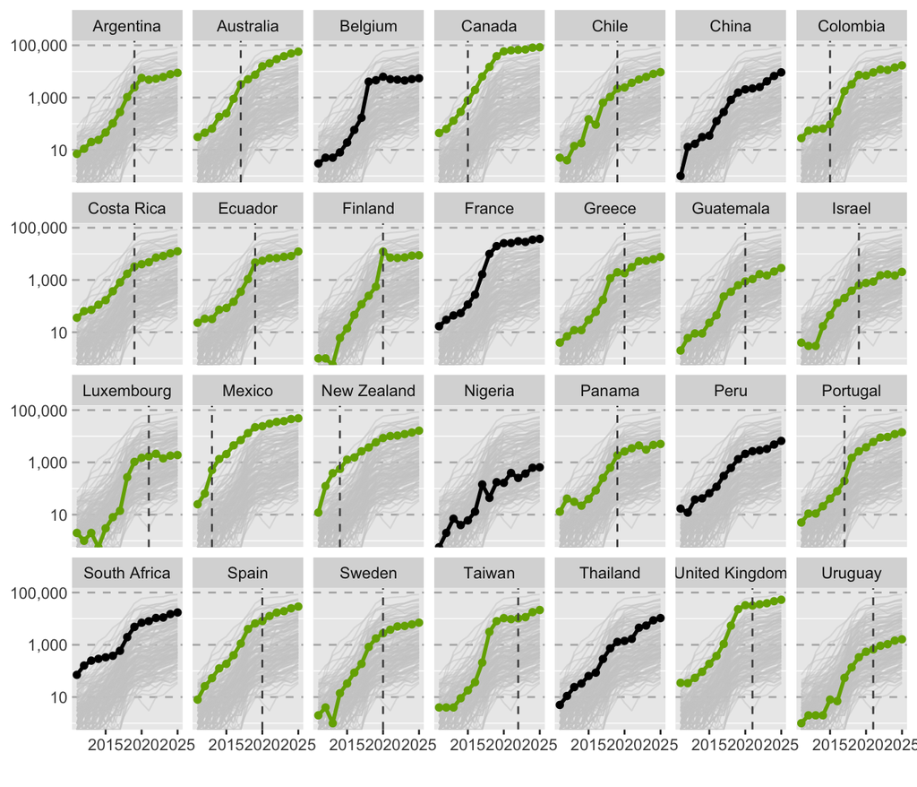

```r
data_temporal_users_plot <- left_join(
  data_variables %>%
    select(-c(n_records, p_research_grade, n_users, n_species, n_projects, n_literature)),
  data_temporal_users) %>%
  mutate(has_node = ifelse(!is.na(node_name), 1, 0))

# split data into highlighted and background
highlighted_nodes <- data_temporal_users_plot %>%
  filter(country_name %in% inat_network$node_country)

highlighted_others <- data_temporal_users_plot %>%
  filter(country_name %in% c('France', 'Peru', 'Thailand',
                             'Belgium', 'Bhtuan', 'China',
                             'South Africa', 'Nigeria'))

node_years <- highlighted_nodes %>%
  distinct(country_name, node_year)

temporal_users_plot_nodes_and_others <- bind_rows(highlighted_nodes, highlighted_others) %>%
  ggplot(aes(x = year, y = n_users_years,
             colour = factor(has_node))) +
  # grey background lines (all countries, in every facet)
  geom_line(
    data = data_temporal_users_plot %>% rename(country_name2 = country_name),
    aes(group = country_name2),
    colour = "grey80", linewidth = 0.4, alpha = 0.5
  ) +
  geom_line( linewidth = 1, show.legend = FALSE) +
  geom_point(size = 1.5, show.legend = FALSE) +
  scale_color_manual(values = c('black','#74AC00')) +
  geom_vline(
    data = node_years,
    aes(xintercept = node_year),
    linetype = "dashed",
    colour = "grey30",
    linewidth = 0.5
  ) +
  scale_y_log10(labels = scales::label_comma()) +
  facet_wrap(~ country_name, ncol = 7) +
  labs(x = "", y = "Number of users (log scale)") +
  ggpubr::theme_cleveland()

temporal_users_plot_nodes <- highlighted_nodes %>%
  ggplot(aes(x = year, y = n_users_years,
             colour = factor(has_node))) +
  # grey background lines (all countries, in every facet)
  geom_line(
    data = data_temporal_users_plot %>% rename(country_name2 = country_name),
    aes(group = country_name2),
    colour = "grey80", linewidth = 0.4, alpha = 0.5
  ) +
  geom_line(col='#74AC00', linewidth = 1, show.legend = FALSE) +
  geom_point(col='#74AC00', size = 1.5, show.legend = FALSE) +
  geom_vline(
    data = node_years,
    aes(xintercept = node_year),
    linetype = "dashed",
    colour = "grey30",
    linewidth = 0.5
  ) +
  scale_y_log10(labels = scales::label_comma()) +
  facet_wrap(~ country_name, ncol = 7) +
  labs(x = "", y = "Number of users (log scale)") +
  ggpubr::theme_cleveland()

temporal_users_plot_nodes_and_others
```

```r
# temporal_plot_nodes
```

#### Nested models

```r
# Null model (random effect only)
m0_users <- lmer(n_users_years ~ year_c + (1 | country_name),
           data = data_temporal_lm, REML = FALSE)

# Add has_node main effect
m1_users <- lmer(n_users_years ~ has_node * year_c + (1 | country_name),
           data = data_temporal_lm, REML = FALSE)

# Full model
m2_users <- lmer(n_users_years ~ has_node * year_c + (1 | country_name) +
             area + population + gdp_per_capita + gdp_in_research +
             iucn_species + latitude + neighbour_has_node,
           data = data_temporal_lm, REML = FALSE)
```

```r
anova_users <- anova(m0_users, m1_users, m2_users)
knitr::kable(tidy(anova_users),
             digits = 3, caption = "Model comparison for n_users_years models")
```

Model comparison for n_users_years models

| term | npar | AIC | BIC | logLik | deviance | statistic | df | p.value |
| --- | --- | --- | --- | --- | --- | --- | --- | --- |
| m0_users | 4 | 1408.033 | 1430.574 | -700.017 | 1400.033 |  |  |  |
| m1_users | 6 | 1287.800 | 1321.612 | -637.900 | 1275.800 | 124.233 | 2 | 0 |
| m2_users | 13 | 1142.007 | 1215.266 | -558.003 | 1116.007 | 159.793 | 7 | 0 |

```r
compare_performance(m0_users, m1_users, m2_users, rank = TRUE)
```

```
# Comparison of Model Performance Indices

Name     |           Model | R2 (cond.) | R2 (marg.) |   ICC |  RMSE | Sigma
----------------------------------------------------------------------------
m2_users | lmerModLmerTest |      0.915 |      0.848 | 0.445 | 0.282 | 0.291
m1_users | lmerModLmerTest |      0.915 |      0.687 | 0.730 | 0.281 | 0.291
m0_users | lmerModLmerTest |      0.912 |      0.598 | 0.781 | 0.287 | 0.297

Name     | AIC weights | AICc weights | BIC weights | Performance-Score
-----------------------------------------------------------------------
m2_users |        1.00 |         1.00 |        1.00 |            86.38%
m1_users |    2.19e-32 |     2.35e-32 |    8.08e-24 |            52.55%
m0_users |    1.71e-58 |     1.85e-58 |    1.76e-47 |            12.50%
```

```r
summary(m2_users)$call
```

```
lmer(formula = n_users_years ~ has_node * year_c + (1 | country_name) +
    area + population + gdp_per_capita + gdp_in_research + iucn_species +
    latitude + neighbour_has_node, data = data_temporal_lm, REML = FALSE)
```

```r
tab_model(m2_users)
```

|  | n users years |  |  |
| --- | --- | --- | --- |
| Predictors | Estimates | CI | p |
| (Intercept) | -0.10 | -0.17 – -0.03 | **0.007** |
| has node [1] | 0.30 | 0.15 – 0.45 | **<0.001** |
| year c | 0.17 | 0.17 – 0.18 | **<0.001** |
| area | 0.03 | -0.05 – 0.12 | 0.445 |
| population | 0.14 | 0.05 – 0.23 | **0.003** |
| gdp per capita | 0.27 | 0.19 – 0.34 | **<0.001** |
| gdp in research | 0.03 | -0.02 – 0.08 | 0.298 |
| iucn species | 0.32 | 0.24 – 0.40 | **<0.001** |
| latitude | 0.10 | 0.02 – 0.17 | **0.010** |
| neighbour has node [1] | 0.04 | -0.08 – 0.16 | 0.479 |
| has node [1] × year c | 0.04 | 0.03 – 0.05 | **<0.001** |
| Random Effects |  |  |  |
| σ<sup>2</sup> | 0.08 |  |  |
| τ<sub>00</sub> <sub>country_name</sub> | 0.07 |  |  |
| ICC | 0.45 |  |  |
| N <sub>country_name</sub> | 138 |  |  |
| Observations | 2070 |  |  |
| Marginal R<sup>2</sup> / Conditional R<sup>2</sup> | 0.848 / 0.915 |  |  |

### Number of species recorded in the country, by year

```r
data_temporal_species <- readRDS('data/archive/temporal_data_download/data_temporal_species.rds')

data_temporal_species <- left_join(
  data_mixed_effects %>%
    select(-c(n_records, p_research_grade, n_users, n_species, n_projects, n_literature)),
  data_temporal_species %>% rename(n_species_years = n_species)) %>%
  mutate(has_node = ifelse(!is.na(node_name), 1, 0))

data_temporal_lm <- data_temporal_species %>%
  mutate(area = scale(log10(area))[,1],
         population = scale(log10(population))[,1],
         gdp_per_capita = scale(log10(gdp_per_capita))[,1],
         latitude = scale(log10(abs(latitude)))[,1],
         iucn_species = scale(log10(iucn_species))[,1],
         has_node = as.factor(has_node),
         neighbour_has_node = as.factor(neighbour_has_node),
         n_species_years = scale(log10(n_species_years+1))[,1])

data_temporal_lm$year_c <- data_temporal_lm$year - mean(data_temporal_lm$year)
data_temporal_lm$has_node <- relevel(factor(data_temporal_lm$has_node), ref = "0")
data_temporal_lm$neighbour_has_node <- relevel(factor(data_temporal_lm$neighbour_has_node), ref = "0")
```

#### Time series plot

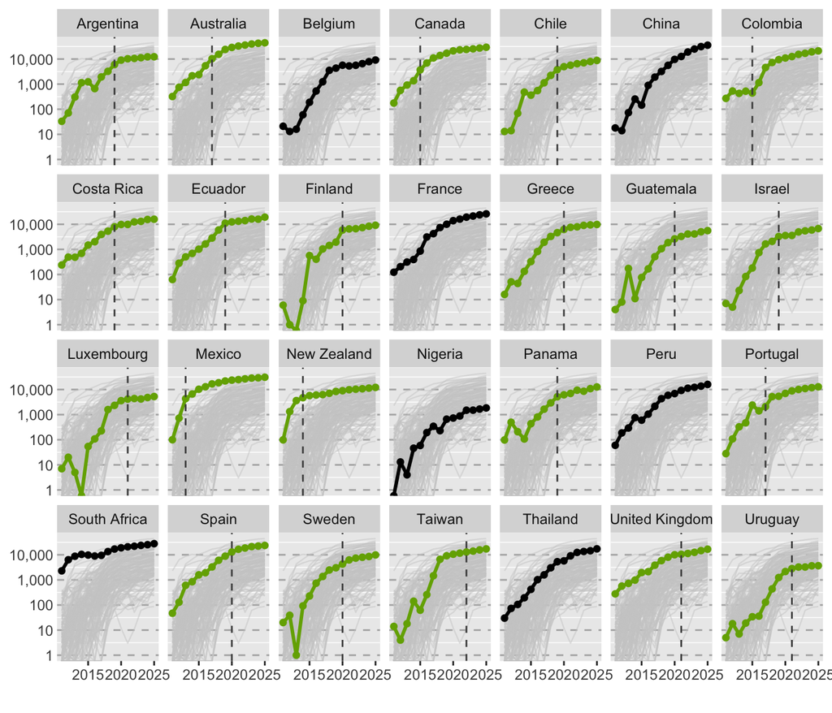

```r
data_temporal_species_plot <- left_join(
  data_variables %>%
    select(-c(n_records, p_research_grade, n_users, n_species, n_projects, n_literature)),
  data_temporal_species) %>%
  mutate(has_node = ifelse(!is.na(node_name), 1, 0))

# split data into highlighted and background
highlighted_nodes <- data_temporal_species_plot %>%
  filter(country_name %in% inat_network$node_country)

highlighted_others <- data_temporal_species_plot %>%
  filter(country_name %in% c('France', 'Peru', 'Thailand',
                             'Belgium', 'Bhtuan', 'China',
                             'South Africa', 'Nigeria'))

node_years <- highlighted_nodes %>%
  distinct(country_name, node_year)

temporal_species_plot_nodes_and_others <- bind_rows(highlighted_nodes, highlighted_others) %>%
  ggplot(aes(x = year, y = n_species_years,
             colour = factor(has_node))) +
  # grey background lines (all countries, in every facet)
  geom_line(
    data = data_temporal_species_plot %>% rename(country_name2 = country_name),
    aes(group = country_name2),
    colour = "grey80", linewidth = 0.4, alpha = 0.5
  ) +
  geom_line( linewidth = 1, show.legend = FALSE) +
  geom_point(size = 1.5, show.legend = FALSE) +
  scale_color_manual(values = c('black','#74AC00')) +
  geom_vline(
    data = node_years,
    aes(xintercept = node_year),
    linetype = "dashed",
    colour = "grey30",
    linewidth = 0.5
  ) +
  scale_y_log10(labels = scales::label_comma()) +
  facet_wrap(~ country_name, ncol = 7) +
  labs(x = "", y = "Number of species (log scale)") +
  ggpubr::theme_cleveland()

temporal_species_plot_nodes <- highlighted_nodes %>%
  ggplot(aes(x = year, y = n_species_years,
             colour = factor(has_node))) +
  # grey background lines (all countries, in every facet)
  geom_line(
    data = data_temporal_species_plot %>% rename(country_name2 = country_name),
    aes(group = country_name2),
    colour = "grey80", linewidth = 0.4, alpha = 0.5
  ) +
  geom_line(col='#74AC00', linewidth = 1, show.legend = FALSE) +
  geom_point(col='#74AC00', size = 1.5, show.legend = FALSE) +
  geom_vline(
    data = node_years,
    aes(xintercept = node_year),
    linetype = "dashed",
    colour = "grey30",
    linewidth = 0.5
  ) +
  scale_y_log10(labels = scales::label_comma()) +
  facet_wrap(~ country_name, ncol = 7) +
  labs(x = "", y = "Number of species (log scale)") +
  ggpubr::theme_cleveland()

temporal_species_plot_nodes_and_others
```

```r
# temporal_plot_nodes
```

#### Nested models

```r
# Null model (random effect only)
m0_species <- lmer(n_species_years ~ year_c + (1 | country_name),
           data = data_temporal_lm, REML = FALSE)

# Add has_node main effect
m1_species <- lmer(n_species_years ~ has_node * year_c + (1 | country_name),
           data = data_temporal_lm, REML = FALSE)

# Full model
m2_species <- lmer(n_species_years ~ has_node * year_c + (1 | country_name) +
             area + population + gdp_per_capita + gdp_in_research +
             iucn_species + latitude + neighbour_has_node,
           data = data_temporal_lm, REML = FALSE)
```

```r
anova_species <- anova(m0_species, m1_species, m2_species)
knitr::kable(tidy(anova_species),
             digits = 3, caption = "Model comparison for n_species_years models")
```

Model comparison for n_species_years models

| term | npar | AIC | BIC | logLik | deviance | statistic | df | p.value |
| --- | --- | --- | --- | --- | --- | --- | --- | --- |
| m0_species | 4 | 2294.653 | 2317.194 | -1143.326 | 2286.653 |  |  |  |
| m1_species | 6 | 2253.060 | 2286.871 | -1120.530 | 2241.060 | 45.593 | 2 | 0 |
| m2_species | 13 | 2117.053 | 2190.312 | -1045.527 | 2091.053 | 150.006 | 7 | 0 |

```r
compare_performance(m0_species, m1_species, m2_species, rank = TRUE)
```

```
# Comparison of Model Performance Indices

Name       |           Model | R2 (cond.) | R2 (marg.) |   ICC |  RMSE | Sigma
------------------------------------------------------------------------------
m2_species | lmerModLmerTest |      0.861 |      0.787 | 0.349 | 0.361 | 0.373
m1_species | lmerModLmerTest |      0.861 |      0.623 | 0.632 | 0.360 | 0.373
m0_species | lmerModLmerTest |      0.860 |      0.561 | 0.681 | 0.362 | 0.374

Name       | AIC weights | AICc weights | BIC weights | Performance-Score
-------------------------------------------------------------------------
m2_species |        1.00 |         1.00 |        1.00 |            78.76%
m1_species |    2.93e-30 |     3.13e-30 |    1.08e-21 |            51.44%
m0_species |    2.72e-39 |     2.94e-39 |    2.81e-28 |            12.50%
```

```r
summary(m2_species)$call
```

```
lmer(formula = n_species_years ~ has_node * year_c + (1 | country_name) +
    area + population + gdp_per_capita + gdp_in_research + iucn_species +
    latitude + neighbour_has_node, data = data_temporal_lm, REML = FALSE)
```

```r
tab_model(m2_species)
```

|  | n species years |  |  |
| --- | --- | --- | --- |
| Predictors | Estimates | CI | p |
| (Intercept) | -0.09 | -0.17 – -0.02 | **0.019** |
| has node [1] | 0.17 | 0.02 – 0.33 | **0.030** |
| year c | 0.18 | 0.17 – 0.18 | **<0.001** |
| area | 0.07 | -0.01 – 0.16 | 0.100 |
| population | 0.05 | -0.04 – 0.15 | 0.289 |
| gdp per capita | 0.20 | 0.12 – 0.27 | **<0.001** |
| gdp in research | 0.04 | -0.01 – 0.10 | 0.122 |
| iucn species | 0.38 | 0.30 – 0.46 | **<0.001** |
| latitude | 0.10 | 0.02 – 0.18 | **0.012** |
| neighbour has node [1] | 0.03 | -0.09 – 0.16 | 0.592 |
| has node [1] × year c | -0.02 | -0.03 – -0.01 | **<0.001** |
| Random Effects |  |  |  |
| σ<sup>2</sup> | 0.14 |  |  |
| τ<sub>00</sub> <sub>country_name</sub> | 0.07 |  |  |
| ICC | 0.35 |  |  |
| N <sub>country_name</sub> | 138 |  |  |
| Observations | 2070 |  |  |
| Marginal R<sup>2</sup> / Conditional R<sup>2</sup> | 0.787 / 0.861 |  |  |

### Number of projects created in the country, by year

> It is not possible to download the number of projects per year

### Proportion of records from iNaturalist that reach “Research Grade”, by year

```r
data_temporal_p_research_grade <- readRDS('data/archive/temporal_data_download/data_temporal_prop_research_grade.rds')

data_temporal_p_research_grade <- left_join(
  data_mixed_effects %>%
    select(-c(n_records, p_research_grade, n_users, n_species, n_projects, n_literature)),
  data_temporal_p_research_grade %>% rename(p_research_grade_years = p_research_grade)) %>%
  mutate(has_node = ifelse(!is.na(node_name), 1, 0))

data_temporal_lm <- data_temporal_p_research_grade %>%
  mutate(area = scale(log10(area))[,1],
         population = scale(log10(population))[,1],
         gdp_per_capita = scale(log10(gdp_per_capita))[,1],
         latitude = scale(log10(abs(latitude)))[,1],
         iucn_species = scale(log10(iucn_species))[,1],
         has_node = as.factor(has_node),
         neighbour_has_node = as.factor(neighbour_has_node),
         p_research_grade_years = scale(log10(p_research_grade_years+1))[,1])

data_temporal_lm$year_c <- data_temporal_lm$year - mean(data_temporal_lm$year)
data_temporal_lm$has_node <- relevel(factor(data_temporal_lm$has_node), ref = "0")
data_temporal_lm$neighbour_has_node <- relevel(factor(data_temporal_lm$neighbour_has_node), ref = "0")
```

#### Time series plot

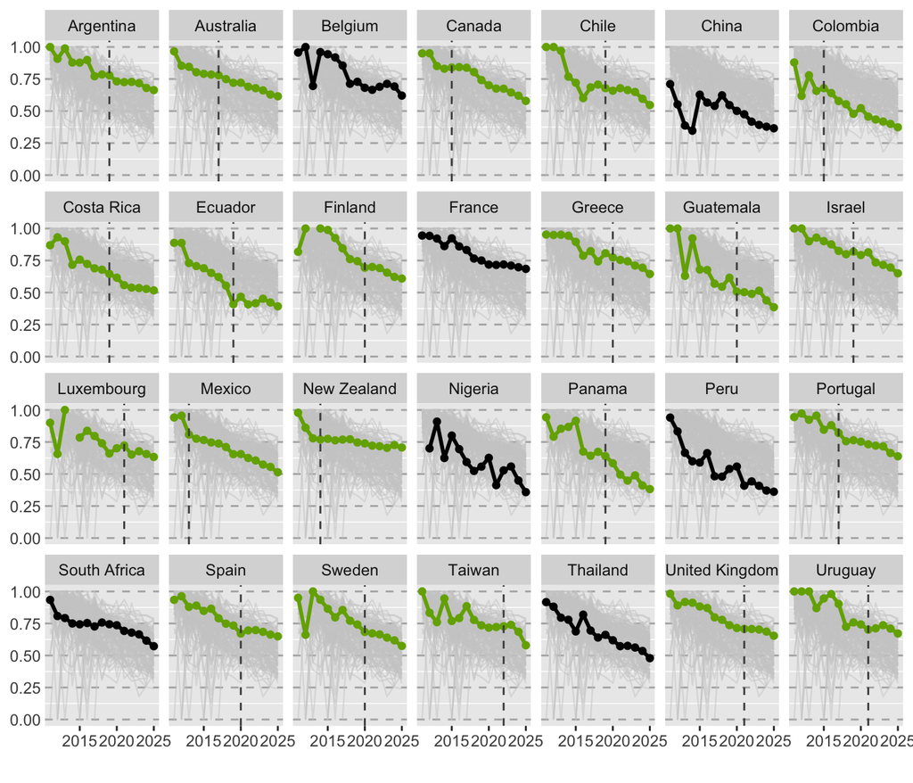

```r
data_temporal_p_research_grade_plot <- left_join(
  data_variables %>%
    select(-c(n_records, p_research_grade, n_users, n_species, n_projects, n_literature)),
  data_temporal_p_research_grade) %>%
  mutate(has_node = ifelse(!is.na(node_name), 1, 0))

# split data into highlighted and background
highlighted_nodes <- data_temporal_p_research_grade_plot %>%
  filter(country_name %in% inat_network$node_country)

highlighted_others <- data_temporal_p_research_grade_plot %>%
  filter(country_name %in% c('France', 'Peru', 'Thailand',
                             'Belgium', 'Bhtuan', 'China',
                             'South Africa', 'Nigeria'))

node_years <- highlighted_nodes %>%
  distinct(country_name, node_year)

temporal_p_research_grade_plot_nodes_and_others <- bind_rows(highlighted_nodes, highlighted_others) %>%
  ggplot(aes(x = year, y = p_research_grade_years,
             colour = factor(has_node))) +
  # grey background lines (all countries, in every facet)
  geom_line(
    data = data_temporal_p_research_grade_plot %>% rename(country_name2 = country_name),
    aes(group = country_name2),
    colour = "grey80", linewidth = 0.4, alpha = 0.5
  ) +
  geom_line( linewidth = 1, show.legend = FALSE) +
  geom_point(size = 1.5, show.legend = FALSE) +
  scale_color_manual(values = c('black','#74AC00')) +
  geom_vline(
    data = node_years,
    aes(xintercept = node_year),
    linetype = "dashed",
    colour = "grey30",
    linewidth = 0.5
  ) +
  # scale_y_log10(labels = scales::label_comma()) +
  facet_wrap(~ country_name, ncol = 7) +
  labs(x = "", y = "Proportion of research grade") +
  ggpubr::theme_cleveland()

temporal_p_research_grade_plot_nodes <- highlighted_nodes %>%
  ggplot(aes(x = year, y = p_research_grade_years,
             colour = factor(has_node))) +
  # grey background lines (all countries, in every facet)
  geom_line(
    data = data_temporal_p_research_grade_plot %>% rename(country_name2 = country_name),
    aes(group = country_name2),
    colour = "grey80", linewidth = 0.4, alpha = 0.5
  ) +
  geom_line(col='#74AC00', linewidth = 1, show.legend = FALSE) +
  geom_point(col='#74AC00', size = 1.5, show.legend = FALSE) +
  geom_vline(
    data = node_years,
    aes(xintercept = node_year),
    linetype = "dashed",
    colour = "grey30",
    linewidth = 0.5
  ) +
  scale_y_log10(labels = scales::label_comma()) +
  facet_wrap(~ country_name, ncol = 7) +
  labs(x = "", y = "Proportion of research grade") +
  ggpubr::theme_cleveland()

temporal_p_research_grade_plot_nodes_and_others
```

```r
# temporal_plot_nodes
```

#### Nested models

```r
# Null model (random effect only)
m0_p_research_grade <- lmer(p_research_grade_years ~ year_c + (1 | country_name),
           data = data_temporal_lm, REML = FALSE)

# Add has_node main effect
m1_p_research_grade <- lmer(p_research_grade_years ~ has_node * year_c + (1 | country_name),
           data = data_temporal_lm, REML = FALSE)

# Full model
m2_p_research_grade <- lmer(p_research_grade_years ~ has_node * year_c + (1 | country_name) +
             area + population + gdp_per_capita + gdp_in_research +
             iucn_species + latitude + neighbour_has_node,
           data = data_temporal_lm, REML = FALSE)
```

```r
anova_p_research_grade <- anova(m0_p_research_grade, m1_p_research_grade, m2_p_research_grade)
knitr::kable(tidy(anova_p_research_grade),
             digits = 3, caption = "Model comparison for p_research_grade_years models")
```

Model comparison for p_research_grade_years models

| term | npar | AIC | BIC | logLik | deviance | statistic | df | p.value |
| --- | --- | --- | --- | --- | --- | --- | --- | --- |
| m0_p_research_grade | 4 | 4266.870 | 4289.177 | -2129.435 | 4258.870 |  |  |  |
| m1_p_research_grade | 6 | 4268.164 | 4301.624 | -2128.082 | 4256.164 | 2.706 | 2 | 0.258 |
| m2_p_research_grade | 13 | 4236.699 | 4309.194 | -2105.349 | 4210.699 | 45.465 | 7 | 0.000 |

```r
compare_performance(m0_p_research_grade, m1_p_research_grade, m2_p_research_grade, rank = TRUE)
```

```
# Comparison of Model Performance Indices

Name                |           Model | R2 (cond.) | R2 (marg.) |   ICC |  RMSE
-------------------------------------------------------------------------------
m0_p_research_grade | lmerModLmerTest |      0.556 |      0.317 | 0.350 | 0.646
m1_p_research_grade | lmerModLmerTest |      0.557 |      0.323 | 0.346 | 0.646
m2_p_research_grade | lmerModLmerTest |      0.553 |      0.394 | 0.263 | 0.648

Name                | Sigma | AIC weights | AICc weights | BIC weights | Performance-Score
------------------------------------------------------------------------------------------
m0_p_research_grade | 0.668 |    2.81e-07 |     3.05e-07 |       0.998 |            55.29%
m1_p_research_grade | 0.668 |    1.47e-07 |     1.58e-07 |       0.002 |            50.28%
m2_p_research_grade | 0.668 |       1.000 |        1.000 |    4.49e-05 |            37.50%
```

```r
summary(m2_p_research_grade)$call
```

```
lmer(formula = p_research_grade_years ~ has_node * year_c + (1 |
    country_name) + area + population + gdp_per_capita + gdp_in_research +
    iucn_species + latitude + neighbour_has_node, data = data_temporal_lm,
    REML = FALSE)
```

```r
tab_model(m2_p_research_grade)
```

|  | p research grade years |  |  |
| --- | --- | --- | --- |
| Predictors | Estimates | CI | p |
| (Intercept) | -0.04 | -0.16 – 0.08 | 0.502 |
| has node [1] | 0.13 | -0.11 – 0.36 | 0.303 |
| year c | -0.13 | -0.14 – -0.13 | **<0.001** |
| area | 0.08 | -0.05 – 0.22 | 0.228 |
| population | -0.02 | -0.17 – 0.12 | 0.767 |
| gdp per capita | 0.11 | -0.01 – 0.23 | 0.066 |
| gdp in research | 0.06 | -0.03 – 0.15 | 0.171 |
| iucn species | -0.19 | -0.31 – -0.06 | **0.003** |
| latitude | 0.04 | -0.08 – 0.15 | 0.536 |
| neighbour has node [1] | 0.03 | -0.16 – 0.22 | 0.776 |
| has node [1] × year c | -0.00 | -0.02 – 0.01 | 0.653 |
| Random Effects |  |  |  |
| σ<sup>2</sup> | 0.45 |  |  |
| τ<sub>00</sub> <sub>country_name</sub> | 0.16 |  |  |
| ICC | 0.26 |  |  |
| N <sub>country_name</sub> | 138 |  |  |
| Observations | 1952 |  |  |
| Marginal R<sup>2</sup> / Conditional R<sup>2</sup> | 0.394 / 0.553 |  |  |

### Number of peer-reviewed publications published in the country, by year

```r
data_temporal_literature <- readRDS('data/archive/temporal_data_download/data_temporal_literature.rds')

data_temporal_literature <- left_join(
  data_mixed_effects %>%
    select(-c(n_records, p_research_grade, n_users, n_species, n_projects, n_literature)),
  data_temporal_literature %>% rename(n_literature_years = n_literature)) %>%
  mutate(has_node = ifelse(!is.na(node_name), 1, 0))

data_temporal_lm <- data_temporal_literature %>%
  mutate(area = scale(log10(area))[,1],
         population = scale(log10(population))[,1],
         gdp_per_capita = scale(log10(gdp_per_capita))[,1],
         latitude = scale(log10(abs(latitude)))[,1],
         iucn_species = scale(log10(iucn_species))[,1],
         has_node = as.factor(has_node),
         neighbour_has_node = as.factor(neighbour_has_node),
         n_literature_years = scale(log10(n_literature_years+1))[,1])

data_temporal_lm$year_c <- data_temporal_lm$year - mean(data_temporal_lm$year)
data_temporal_lm$has_node <- relevel(factor(data_temporal_lm$has_node), ref = "0")
data_temporal_lm$neighbour_has_node <- relevel(factor(data_temporal_lm$neighbour_has_node), ref = "0")
```

#### Time series plot

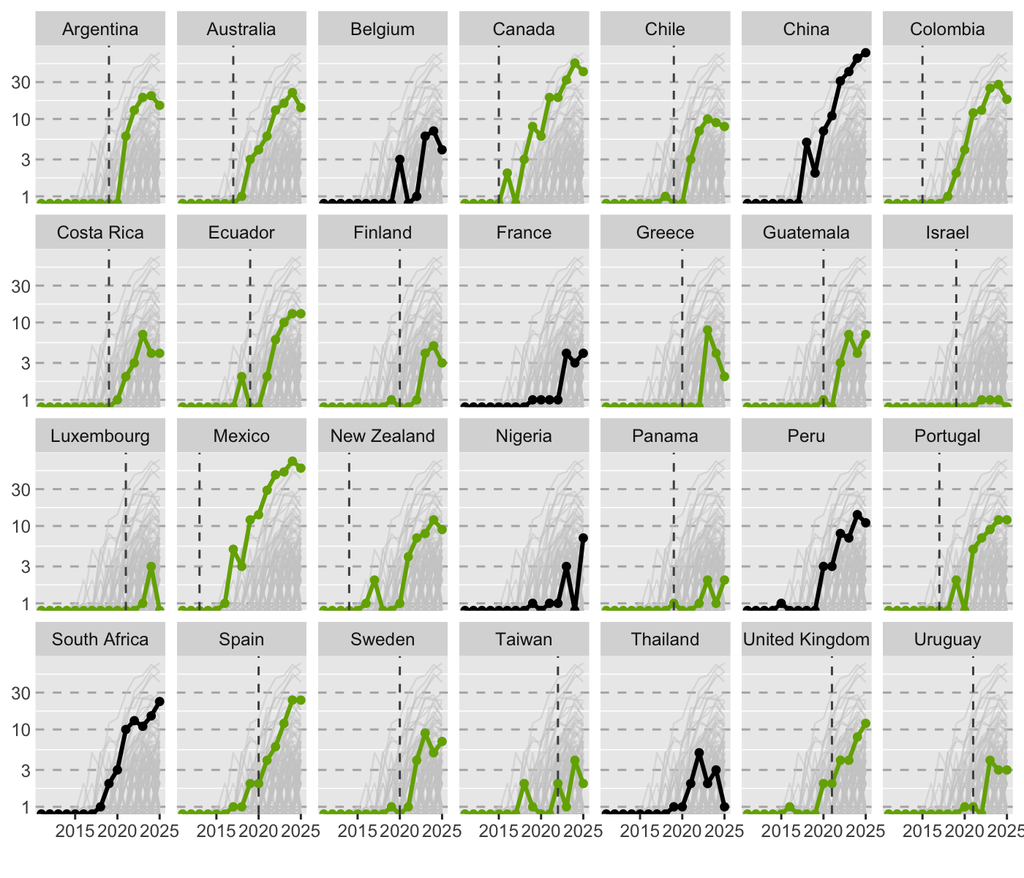

```r
data_temporal_literature_plot <- left_join(
  data_variables %>%
    select(-c(n_records, p_research_grade, n_users, n_species, n_projects, n_literature)),
  data_temporal_literature) %>%
  mutate(has_node = ifelse(!is.na(node_name), 1, 0))

# split data into highlighted and background
highlighted_nodes <- data_temporal_literature_plot %>%
  filter(country_name %in% inat_network$node_country)

highlighted_others <- data_temporal_literature_plot %>%
  filter(country_name %in% c('France', 'Peru', 'Thailand',
                             'Belgium', 'Bhtuan', 'China',
                             'South Africa', 'Nigeria'))

node_years <- highlighted_nodes %>%
  distinct(country_name, node_year)

temporal_literature_plot_nodes_and_others <- bind_rows(highlighted_nodes, highlighted_others) %>%
  ggplot(aes(x = year, y = n_literature_years,
             colour = factor(has_node))) +
  # grey background lines (all countries, in every facet)
  geom_line(
    data = data_temporal_literature_plot %>% rename(country_name2 = country_name),
    aes(group = country_name2),
    colour = "grey80", linewidth = 0.4, alpha = 0.5
  ) +
  geom_line( linewidth = 1, show.legend = FALSE) +
  geom_point(size = 1.5, show.legend = FALSE) +
  scale_color_manual(values = c('black','#74AC00')) +
  geom_vline(
    data = node_years,
    aes(xintercept = node_year),
    linetype = "dashed",
    colour = "grey30",
    linewidth = 0.5
  ) +
  scale_y_log10(labels = scales::label_comma()) +
  facet_wrap(~ country_name, ncol = 7) +
  labs(x = "", y = "Number of literature (log scale)") +
  ggpubr::theme_cleveland()

temporal_literature_plot_nodes <- highlighted_nodes %>%
  ggplot(aes(x = year, y = n_literature_years,
             colour = factor(has_node))) +
  # grey background lines (all countries, in every facet)
  geom_line(
    data = data_temporal_literature_plot %>% rename(country_name2 = country_name),
    aes(group = country_name2),
    colour = "grey80", linewidth = 0.4, alpha = 0.5
  ) +
  geom_line(col='#74AC00', linewidth = 1, show.legend = FALSE) +
  geom_point(col='#74AC00', size = 1.5, show.legend = FALSE) +
  geom_vline(
    data = node_years,
    aes(xintercept = node_year),
    linetype = "dashed",
    colour = "grey30",
    linewidth = 0.5
  ) +
  scale_y_log10(labels = scales::label_comma()) +
  facet_wrap(~ country_name, ncol = 7) +
  labs(x = "", y = "Number of literature (log scale)") +
  ggpubr::theme_cleveland()

temporal_literature_plot_nodes_and_others
```

```r
# temporal_plot_nodes
```

#### Nested models

```r
# Null model (random effect only)
m0_literature <- lmer(n_literature_years ~ year_c + (1 | country_name),
           data = data_temporal_lm, REML = FALSE)

# Add has_node main effect
m1_literature <- lmer(n_literature_years ~ has_node * year_c + (1 | country_name),
           data = data_temporal_lm, REML = FALSE)

# Full model
m2_literature <- lmer(n_literature_years ~ has_node * year_c + (1 | country_name) +
             area + population + gdp_per_capita + gdp_in_research +
             iucn_species + latitude + neighbour_has_node,
           data = data_temporal_lm, REML = FALSE)
```

```r
anova_literature <- anova(m0_literature, m1_literature, m2_literature)
knitr::kable(tidy(anova_literature),
             digits = 3, caption = "Model comparison for n_literature_years models")
```

Model comparison for n_literature_years models

| term | npar | AIC | BIC | logLik | deviance | statistic | df | p.value |
| --- | --- | --- | --- | --- | --- | --- | --- | --- |
| m0_literature | 4 | 4944.322 | 4967.170 | -2468.161 | 4936.322 |  |  |  |
| m1_literature | 6 | 4764.500 | 4798.772 | -2376.250 | 4752.500 | 183.822 | 2 | 0 |
| m2_literature | 13 | 4649.079 | 4723.335 | -2311.540 | 4623.079 | 129.421 | 7 | 0 |

```r
compare_performance(m0_literature, m1_literature, m2_literature, rank = TRUE)
```

```
# Comparison of Model Performance Indices

Name          |           Model | R2 (cond.) | R2 (marg.) |   ICC |  RMSE
-------------------------------------------------------------------------
m2_literature | lmerModLmerTest |      0.565 |      0.519 | 0.097 | 0.645
m1_literature | lmerModLmerTest |      0.565 |      0.414 | 0.259 | 0.640
m0_literature | lmerModLmerTest |      0.531 |      0.348 | 0.281 | 0.665

Name          | Sigma | AIC weights | AICc weights | BIC weights | Performance-Score
------------------------------------------------------------------------------------
m2_literature | 0.659 |        1.00 |         1.00 |        1.00 |            84.93%
m1_literature | 0.659 |    8.64e-26 |     9.21e-26 |    4.16e-17 |            53.29%
m0_literature | 0.685 |    7.74e-65 |     8.33e-65 |    1.13e-53 |            12.50%
```

```r
summary(m2_literature)$call
```

```
lmer(formula = n_literature_years ~ has_node * year_c + (1 |
    country_name) + area + population + gdp_per_capita + gdp_in_research +
    iucn_species + latitude + neighbour_has_node, data = data_temporal_lm,
    REML = FALSE)
```

```r
tab_model(m2_literature)
```

|  | n literature years |  |  |
| --- | --- | --- | --- |
| Predictors | Estimates | CI | p |
| (Intercept) | -0.03 | -0.10 – 0.05 | 0.480 |
| has node [1] | 0.18 | 0.03 – 0.33 | **0.017** |
| year c | 0.12 | 0.11 – 0.13 | **<0.001** |
| area | 0.10 | 0.02 – 0.18 | **0.011** |
| population | 0.12 | 0.04 – 0.21 | **0.005** |
| gdp per capita | 0.14 | 0.07 – 0.21 | **<0.001** |
| gdp in research | -0.02 | -0.08 – 0.03 | 0.385 |
| iucn species | 0.20 | 0.13 – 0.28 | **<0.001** |
| latitude | 0.09 | 0.02 – 0.15 | **0.006** |
| neighbour has node [1] | 0.09 | -0.03 – 0.20 | 0.140 |
| has node [1] × year c | 0.12 | 0.10 – 0.14 | **<0.001** |
| Random Effects |  |  |  |
| σ<sup>2</sup> | 0.43 |  |  |
| τ<sub>00</sub> <sub>country_name</sub> | 0.05 |  |  |
| ICC | 0.10 |  |  |
| N <sub>country_name</sub> | 149 |  |  |
| Observations | 2235 |  |  |
| Marginal R<sup>2</sup> / Conditional R<sup>2</sup> | 0.519 / 0.565 |  |  |

### Model performance

```r
bind_rows(tidy(anova_records),
          tidy(anova_users),
          tidy(anova_species),
          tidy(anova_p_research_grade),
          tidy(anova_literature)) %>%
  knitr::kable(digits = 1, caption = "All models")
```

All models

| term | npar | AIC | BIC | logLik | deviance | statistic | df | p.value |
| --- | --- | --- | --- | --- | --- | --- | --- | --- |
| m0_records | 4 | 1681.3 | 1703.9 | -836.7 | 1673.3 |  |  |  |
| m1_records | 6 | 1643.7 | 1677.5 | -815.8 | 1631.7 | 41.6 | 2 | 0.0 |
| m2_records | 13 | 1514.5 | 1587.8 | -744.3 | 1488.5 | 143.1 | 7 | 0.0 |
| m0_users | 4 | 1408.0 | 1430.6 | -700.0 | 1400.0 |  |  |  |
| m1_users | 6 | 1287.8 | 1321.6 | -637.9 | 1275.8 | 124.2 | 2 | 0.0 |
| m2_users | 13 | 1142.0 | 1215.3 | -558.0 | 1116.0 | 159.8 | 7 | 0.0 |
| m0_species | 4 | 2294.7 | 2317.2 | -1143.3 | 2286.7 |  |  |  |
| m1_species | 6 | 2253.1 | 2286.9 | -1120.5 | 2241.1 | 45.6 | 2 | 0.0 |
| m2_species | 13 | 2117.1 | 2190.3 | -1045.5 | 2091.1 | 150.0 | 7 | 0.0 |
| m0_p_research_grade | 4 | 4266.9 | 4289.2 | -2129.4 | 4258.9 |  |  |  |
| m1_p_research_grade | 6 | 4268.2 | 4301.6 | -2128.1 | 4256.2 | 2.7 | 2 | 0.3 |
| m2_p_research_grade | 13 | 4236.7 | 4309.2 | -2105.3 | 4210.7 | 45.5 | 7 | 0.0 |
| m0_literature | 4 | 4944.3 | 4967.2 | -2468.2 | 4936.3 |  |  |  |
| m1_literature | 6 | 4764.5 | 4798.8 | -2376.2 | 4752.5 | 183.8 | 2 | 0.0 |
| m2_literature | 13 | 4649.1 | 4723.3 | -2311.5 | 4623.1 | 129.4 | 7 | 0.0 |

```r
print('Number of records per year');performance::performance(m0_records)
```

```
[1] "Number of records per year"
```

```
# Indices of model performance

AIC    |   AICc |    BIC | R2 (cond.) | R2 (marg.) |   ICC |  RMSE | Sigma
--------------------------------------------------------------------------
1696.6 | 1696.6 | 1719.1 |      0.898 |      0.596 | 0.747 | 0.309 | 0.319
```

```r
print('Number of users per year');performance::performance(m0_users)
```

```
[1] "Number of users per year"
```

```
# Indices of model performance

AIC    |   AICc |    BIC | R2 (cond.) | R2 (marg.) |   ICC |  RMSE | Sigma
--------------------------------------------------------------------------
1423.4 | 1423.4 | 1446.0 |      0.912 |      0.598 | 0.781 | 0.287 | 0.297
```

```r
print('Number of species per year');performance::performance(m0_species)
```

```
[1] "Number of species per year"
```

```
# Indices of model performance

AIC    |   AICc |    BIC | R2 (cond.) | R2 (marg.) |   ICC |  RMSE | Sigma
--------------------------------------------------------------------------
2309.6 | 2309.6 | 2332.1 |      0.860 |      0.561 | 0.681 | 0.362 | 0.374
```

```r
print('Proportion of research-grade per year');performance::performance(m0_p_research_grade)
```

```
[1] "Proportion of research-grade per year"
```

```
# Indices of model performance

AIC    |   AICc |    BIC | R2 (cond.) | R2 (marg.) |   ICC |  RMSE | Sigma
--------------------------------------------------------------------------
4280.7 | 4280.7 | 4303.0 |      0.556 |      0.317 | 0.350 | 0.646 | 0.668
```

```r
print('Number of derived publications per year');performance::performance(m0_literature)
```

```
[1] "Number of derived publications per year"
```

```
# Indices of model performance

AIC    |   AICc |    BIC | R2 (cond.) | R2 (marg.) |   ICC |  RMSE | Sigma
--------------------------------------------------------------------------
4958.6 | 4958.6 | 4981.4 |      0.531 |      0.348 | 0.281 | 0.665 | 0.685
```

```r
tab_model(m0_records, m0_users, m0_species, m0_p_research_grade, m0_literature)
```

[output not shown]

```r
print('Number of records per year');performance::performance(m1_records)
```

```
[1] "Number of records per year"
```

```
# Indices of model performance

AIC    |   AICc |    BIC | R2 (cond.) | R2 (marg.) |   ICC |  RMSE | Sigma
--------------------------------------------------------------------------
1670.6 | 1670.7 | 1704.4 |      0.898 |      0.666 | 0.696 | 0.308 | 0.319
```

```r
print('Number of users per year');performance::performance(m1_users)
```

```
[1] "Number of users per year"
```

```
# Indices of model performance

AIC    |   AICc |    BIC | R2 (cond.) | R2 (marg.) |   ICC |  RMSE | Sigma
--------------------------------------------------------------------------
1315.2 | 1315.2 | 1349.0 |      0.915 |      0.687 | 0.730 | 0.281 | 0.291
```

```r
print('Number of species per year');performance::performance(m1_species)
```

```
[1] "Number of species per year"
```

```
# Indices of model performance

AIC    |   AICc |    BIC | R2 (cond.) | R2 (marg.) |   ICC |  RMSE | Sigma
--------------------------------------------------------------------------
2279.3 | 2279.4 | 2313.1 |      0.861 |      0.623 | 0.632 | 0.360 | 0.373
```

```r
print('Proportion of research-grade per year');performance::performance(m1_p_research_grade)
```

```
[1] "Proportion of research-grade per year"
```

```
# Indices of model performance

AIC    |   AICc |    BIC | R2 (cond.) | R2 (marg.) |   ICC |  RMSE | Sigma
--------------------------------------------------------------------------
4291.8 | 4291.8 | 4325.3 |      0.557 |      0.323 | 0.346 | 0.646 | 0.668
```

```r
print('Number of derived publications per year');performance::performance(m1_literature)
```

```
[1] "Number of derived publications per year"
```

```
# Indices of model performance

AIC    |   AICc |    BIC | R2 (cond.) | R2 (marg.) |   ICC |  RMSE | Sigma
--------------------------------------------------------------------------
4789.3 | 4789.3 | 4823.6 |      0.565 |      0.414 | 0.259 | 0.640 | 0.659
```

```r
tab_model(m1_records, m1_users, m1_species, m1_p_research_grade, m1_literature)
```

|  | n records years |  |  | n users years |  |  | n species years |  |  | p research grade years |  |  | n literature years |  |  |
| --- | --- | --- | --- | --- | --- | --- | --- | --- | --- | --- | --- | --- | --- | --- | --- |
| Predictors | Estimates | CI | p | Estimates | CI | p | Estimates | CI | p | Estimates | CI | p | Estimates | CI | p |
| (Intercept) | -0.11 | -0.20 – -0.02 | **0.014** | -0.12 | -0.21 – -0.04 | **0.006** | -0.10 | -0.19 – -0.01 | **0.023** | 0.01 | -0.08 – 0.11 | 0.782 | -0.07 | -0.15 – -0.00 | **0.046** |
| has node [1] | 0.73 | 0.50 – 0.96 | **<0.001** | 0.82 | 0.59 – 1.04 | **<0.001** | 0.69 | 0.45 – 0.92 | **<0.001** | 0.19 | -0.05 – 0.43 | 0.114 | 0.53 | 0.33 – 0.73 | **<0.001** |
| year c | 0.18 | 0.17 – 0.18 | **<0.001** | 0.17 | 0.17 – 0.18 | **<0.001** | 0.18 | 0.17 – 0.18 | **<0.001** | -0.13 | -0.14 – -0.13 | **<0.001** | 0.12 | 0.11 – 0.13 | **<0.001** |
| has node [1] × year c | 0.01 | 0.00 – 0.02 | **0.010** | 0.04 | 0.03 – 0.05 | **<0.001** | -0.02 | -0.03 – -0.01 | **<0.001** | -0.00 | -0.02 – 0.01 | 0.624 | 0.12 | 0.10 – 0.14 | **<0.001** |
| Random Effects |  |  |  |  |  |  |  |  |  |  |  |  |  |  |  |
| σ<sup>2</sup> | 0.10 |  |  | 0.08 |  |  | 0.14 |  |  | 0.45 |  |  | 0.43 |  |  |
| τ<sub>00</sub> | 0.23 <sub>country_name</sub> |  |  | 0.23 <sub>country_name</sub> |  |  | 0.24 <sub>country_name</sub> |  |  | 0.24 <sub>country_name</sub> |  |  | 0.15 <sub>country_name</sub> |  |  |
| ICC | 0.70 |  |  | 0.73 |  |  | 0.63 |  |  | 0.35 |  |  | 0.26 |  |  |
| N | 149 <sub>country_name</sub> |  |  | 149 <sub>country_name</sub> |  |  | 149 <sub>country_name</sub> |  |  | 149 <sub>country_name</sub> |  |  | 149 <sub>country_name</sub> |  |  |
| Observations | 2070 |  |  | 2070 |  |  | 2070 |  |  | 1952 |  |  | 2235 |  |  |
| Marginal R<sup>2</sup> / Conditional R<sup>2</sup> | 0.666 / 0.898 |  |  | 0.687 / 0.915 |  |  | 0.623 / 0.861 |  |  | 0.323 / 0.557 |  |  | 0.414 / 0.565 |  |  |

```r
print('Number of records per year');performance::performance(m2_records)
```

```
[1] "Number of records per year"
```

```
# Indices of model performance

AIC    |   AICc |    BIC | R2 (cond.) | R2 (marg.) |   ICC |  RMSE | Sigma
--------------------------------------------------------------------------
1577.4 | 1577.5 | 1650.6 |      0.898 |      0.820 | 0.435 | 0.309 | 0.319
```

```r
print('Number of users per year');performance::performance(m2_users)
```

```
[1] "Number of users per year"
```

```
# Indices of model performance

AIC    |   AICc |    BIC | R2 (cond.) | R2 (marg.) |   ICC |  RMSE | Sigma
--------------------------------------------------------------------------
1206.5 | 1206.7 | 1279.7 |      0.915 |      0.848 | 0.445 | 0.282 | 0.291
```

```r
print('Number of species per year');performance::performance(m2_species)
```

```
[1] "Number of species per year"
```

```
# Indices of model performance

AIC    |   AICc |    BIC | R2 (cond.) | R2 (marg.) |   ICC |  RMSE | Sigma
--------------------------------------------------------------------------
2179.4 | 2179.6 | 2252.6 |      0.861 |      0.787 | 0.349 | 0.361 | 0.373
```

```r
print('Proportion of research-grade per year');performance::performance(m2_p_research_grade)
```

```
[1] "Proportion of research-grade per year"
```

```
# Indices of model performance

AIC    |   AICc |    BIC | R2 (cond.) | R2 (marg.) |   ICC |  RMSE | Sigma
--------------------------------------------------------------------------
4289.1 | 4289.3 | 4361.6 |      0.553 |      0.394 | 0.263 | 0.648 | 0.668
```

```r
print('Number of derived publications per year');performance::performance(m2_literature)
```

```
[1] "Number of derived publications per year"
```

```
# Indices of model performance

AIC    |   AICc |    BIC | R2 (cond.) | R2 (marg.) |   ICC |  RMSE | Sigma
--------------------------------------------------------------------------
4711.0 | 4711.2 | 4785.3 |      0.565 |      0.519 | 0.097 | 0.645 | 0.659
```

```r
tab_model(m2_records, m2_users, m2_species, m2_p_research_grade, m2_literature)
```

|  | n records years |  |  | n users years |  |  | n species years |  |  | p research grade years |  |  | n literature years |  |  |
| --- | --- | --- | --- | --- | --- | --- | --- | --- | --- | --- | --- | --- | --- | --- | --- |
| Predictors | Estimates | CI | p | Estimates | CI | p | Estimates | CI | p | Estimates | CI | p | Estimates | CI | p |
| (Intercept) | -0.10 | -0.18 – -0.02 | **0.015** | -0.10 | -0.17 – -0.03 | **0.007** | -0.09 | -0.17 – -0.02 | **0.019** | -0.04 | -0.16 – 0.08 | 0.502 | -0.03 | -0.10 – 0.05 | 0.480 |
| has node [1] | 0.24 | 0.08 – 0.40 | **0.003** | 0.30 | 0.15 – 0.45 | **<0.001** | 0.17 | 0.02 – 0.33 | **0.030** | 0.13 | -0.11 – 0.36 | 0.303 | 0.18 | 0.03 – 0.33 | **0.017** |
| year c | 0.18 | 0.17 – 0.18 | **<0.001** | 0.17 | 0.17 – 0.18 | **<0.001** | 0.18 | 0.17 – 0.18 | **<0.001** | -0.13 | -0.14 – -0.13 | **<0.001** | 0.12 | 0.11 – 0.13 | **<0.001** |
| area | 0.08 | -0.01 – 0.17 | 0.091 | 0.03 | -0.05 – 0.12 | 0.445 | 0.07 | -0.01 – 0.16 | 0.100 | 0.08 | -0.05 – 0.22 | 0.228 | 0.10 | 0.02 – 0.18 | **0.011** |
| population | 0.08 | -0.01 – 0.18 | 0.089 | 0.14 | 0.05 – 0.23 | **0.003** | 0.05 | -0.04 – 0.15 | 0.289 | -0.02 | -0.17 – 0.12 | 0.767 | 0.12 | 0.04 – 0.21 | **0.005** |
| gdp per capita | 0.22 | 0.14 – 0.30 | **<0.001** | 0.27 | 0.19 – 0.34 | **<0.001** | 0.20 | 0.12 – 0.27 | **<0.001** | 0.11 | -0.01 – 0.23 | 0.066 | 0.14 | 0.07 – 0.21 | **<0.001** |
| gdp in research | 0.04 | -0.01 – 0.10 | 0.123 | 0.03 | -0.02 – 0.08 | 0.298 | 0.04 | -0.01 – 0.10 | 0.122 | 0.06 | -0.03 – 0.15 | 0.171 | -0.02 | -0.08 – 0.03 | 0.385 |
| iucn species | 0.33 | 0.25 – 0.42 | **<0.001** | 0.32 | 0.24 – 0.40 | **<0.001** | 0.38 | 0.30 – 0.46 | **<0.001** | -0.19 | -0.31 – -0.06 | **0.003** | 0.20 | 0.13 – 0.28 | **<0.001** |
| latitude | 0.08 | 0.00 – 0.16 | **0.039** | 0.10 | 0.02 – 0.17 | **0.010** | 0.10 | 0.02 – 0.18 | **0.012** | 0.04 | -0.08 – 0.15 | 0.536 | 0.09 | 0.02 – 0.15 | **0.006** |
| neighbour has node [1] | 0.01 | -0.11 – 0.14 | 0.859 | 0.04 | -0.08 – 0.16 | 0.479 | 0.03 | -0.09 – 0.16 | 0.592 | 0.03 | -0.16 – 0.22 | 0.776 | 0.09 | -0.03 – 0.20 | 0.140 |
| has node [1] × year c | 0.01 | 0.00 – 0.02 | **0.010** | 0.04 | 0.03 – 0.05 | **<0.001** | -0.02 | -0.03 – -0.01 | **<0.001** | -0.00 | -0.02 – 0.01 | 0.653 | 0.12 | 0.10 – 0.14 | **<0.001** |
| Random Effects |  |  |  |  |  |  |  |  |  |  |  |  |  |  |  |
| σ<sup>2</sup> | 0.10 |  |  | 0.08 |  |  | 0.14 |  |  | 0.45 |  |  | 0.43 |  |  |
| τ<sub>00</sub> | 0.08 <sub>country_name</sub> |  |  | 0.07 <sub>country_name</sub> |  |  | 0.07 <sub>country_name</sub> |  |  | 0.16 <sub>country_name</sub> |  |  | 0.05 <sub>country_name</sub> |  |  |
| ICC | 0.43 |  |  | 0.45 |  |  | 0.35 |  |  | 0.26 |  |  | 0.10 |  |  |
| N | 149 <sub>country_name</sub> |  |  | 149 <sub>country_name</sub> |  |  | 149 <sub>country_name</sub> |  |  | 149 <sub>country_name</sub> |  |  | 149 <sub>country_name</sub> |  |  |
| Observations | 2070 |  |  | 2070 |  |  | 2070 |  |  | 1952 |  |  | 2235 |  |  |
| Marginal R<sup>2</sup> / Conditional R<sup>2</sup> | 0.820 / 0.898 |  |  | 0.848 / 0.915 |  |  | 0.787 / 0.861 |  |  | 0.394 / 0.553 |  |  | 0.519 / 0.565 |  |  |

#### Plot

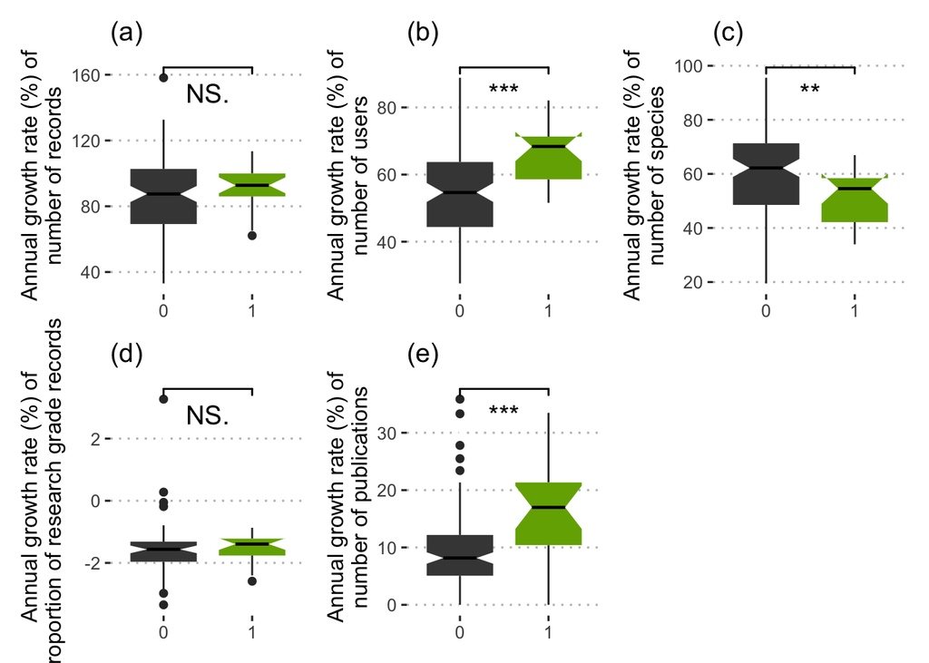

```r
cumulative_numbers <- function(data_temporal, variable_name, plot=T) {

  cagr_df <- data_temporal %>%
    select(country_name, has_node, year, !!sym(variable_name)) %>%
    arrange(country_name, year) %>%
    group_by(country_name, has_node) %>%
    summarise(
      first_year = min(year),
      last_year = max(year),
      n_years = last_year - first_year,
      first_val = (!!sym(variable_name))[year == first_year] + 1,
      last_val  = (!!sym(variable_name))[year == last_year] + 1,
      cagr_pct = ((last_val / first_val)^(1 / n_years) - 1) * 100,
      .groups = "drop"
    )

  cagr_df$has_node <- factor(cagr_df$has_node, labels = c("0", "1"))

  labels <- c(n_records_years = "number of records",
              n_users_years = "number of users",
              n_species_years = "number of species",
              p_research_grade_years = "proportion of research grade records",
              n_literature_years = "number of publications")

  y_label <- str_glue("Annual growth rate (%) of\n{labels[[variable_name]]}")

  letter_plot <- c(n_records_years = '(a)',
                   n_users_years = '(b)',
                   n_species_years = '(c)',
                   p_research_grade_years = '(d)',
                   n_literature_years = '(e)')

  # boxplot comparing node vs no-node
  if(plot){
    ggplot(cagr_df, aes(x = has_node, y = cagr_pct, fill = has_node)) +
      geom_boxplot(notch = T, linewidth = 0,
                 median.color = "black",
                 whisker.linewidth = 0.5,
                 median.linewidth = 0.8,
                 show.legend = F) +
      scale_fill_manual(values = c('#454545', '#74AC00')) +
      # geom_jitter(width = 0.1, alpha = 0.5, size = 2, show.legend = F) +
      ggsignif::geom_signif(comparisons = list(c("0", "1")),
                            map_signif_level = TRUE,
                            textsize = 5, vjust = 2) +
      labs(x = NULL, y = y_label) +
      ggpubr::theme_pubclean() + ggtitle(letter_plot[[variable_name]])
    # theme(legend.position = "none")
  } else {
    print(variable_name)
    print(wilcox.test(cagr_pct ~ has_node, data = cagr_df))
    }
}

cumulative_numbers(data_temporal = data_temporal_records,
                   variable_name = 'n_records_years') +
cumulative_numbers(data_temporal = data_temporal_users,
                   variable_name = 'n_users_years') +
cumulative_numbers(data_temporal = data_temporal_species,
                   variable_name = 'n_species_years') +
cumulative_numbers(data_temporal = data_temporal_p_research_grade,
                   variable_name = 'p_research_grade_years') +
cumulative_numbers(data_temporal = data_temporal_literature,
                   variable_name = 'n_literature_years')
```

```r
cumulative_numbers(data_temporal = data_temporal_records,
                   variable_name = 'n_records_years', plot=F)
```

```
[1] "n_records_years"

    Wilcoxon rank sum test with continuity correction

data:  cagr_pct by has_node
W = 1066, p-value = 0.3369
alternative hypothesis: true location shift is not equal to 0
```

```r
cumulative_numbers(data_temporal = data_temporal_users,
                   variable_name = 'n_users_years', plot=F)
```

```
[1] "n_users_years"

    Wilcoxon rank sum test with continuity correction

data:  cagr_pct by has_node
W = 571, p-value = 0.00009842
alternative hypothesis: true location shift is not equal to 0
```

```r
cumulative_numbers(data_temporal = data_temporal_species,
                   variable_name = 'n_species_years', plot=F)
```

```
[1] "n_species_years"

    Wilcoxon rank sum test with continuity correction

data:  cagr_pct by has_node
W = 1682, p-value = 0.007248
alternative hypothesis: true location shift is not equal to 0
```

```r
cumulative_numbers(data_temporal = data_temporal_p_research_grade,
                   variable_name = 'p_research_grade_years', plot=F)
```

```
[1] "p_research_grade_years"

    Wilcoxon rank sum test with continuity correction

data:  cagr_pct by has_node
W = 618, p-value = 0.3119
alternative hypothesis: true location shift is not equal to 0
```

```r
cumulative_numbers(data_temporal = data_temporal_literature,
                   variable_name = 'n_literature_years', plot=F)
```

```
[1] "n_literature_years"

    Wilcoxon rank sum test with continuity correction

data:  cagr_pct by has_node
W = 674.5, p-value = 0.0002307
alternative hypothesis: true location shift is not equal to 0
```

## Before and after the node

- `node_year`: the year in which a country’s national node was officially established (e.g., 2021 for Uruguay’s NaturalistaUY).
- `years_since_node`: the number of years between the assessed year and the node’s establishment year, calculated as `year - node_year`. This is negative for years before the node existed, zero in the year of establishment, and positive for years after.
- `post_node`: a binary indicator equal to `1` if the assessed year is greater than or equal to `node_year` (i.e., the node already existed that year), and `0` otherwise.

### Number of records

```r
data_before_after_records <- left_join(node_years,
          data_temporal_records %>%
            select(country_name, node_name, year, n_records_years)) %>%
  mutate(years_since_node = year - node_year,
         post_node = ifelse(year >= node_year, 1,0)) %>%
  group_by(country_name) %>%
  mutate(n_records_years = scale(log10(n_records_years+1))[,1])

data_before_after_records %>%
  filter(country_name=='Uruguay') %>% knitr::kable(digits = 3)
```

| country_name | node_year | node_name | year | n_records_years | years_since_node | post_node |
| --- | --- | --- | --- | --- | --- | --- |
| Uruguay | 2021 | NaturalistaUY | 2011 | -1.433 | -10 | 0 |
| Uruguay | 2021 | NaturalistaUY | 2012 | -1.065 | -9 | 0 |
| Uruguay | 2021 | NaturalistaUY | 2013 | -1.314 | -8 | 0 |
| Uruguay | 2021 | NaturalistaUY | 2014 | -1.026 | -7 | 0 |
| Uruguay | 2021 | NaturalistaUY | 2015 | -0.777 | -6 | 0 |
| Uruguay | 2021 | NaturalistaUY | 2016 | -0.810 | -5 | 0 |
| Uruguay | 2021 | NaturalistaUY | 2017 | -0.318 | -4 | 0 |
| Uruguay | 2021 | NaturalistaUY | 2018 | 0.100 | -3 | 0 |
| Uruguay | 2021 | NaturalistaUY | 2019 | 0.480 | -2 | 0 |
| Uruguay | 2021 | NaturalistaUY | 2020 | 0.797 | -1 | 0 |
| Uruguay | 2021 | NaturalistaUY | 2021 | 0.908 | 0 | 1 |
| Uruguay | 2021 | NaturalistaUY | 2022 | 1.057 | 1 | 1 |
| Uruguay | 2021 | NaturalistaUY | 2023 | 1.099 | 2 | 1 |
| Uruguay | 2021 | NaturalistaUY | 2024 | 1.146 | 3 | 1 |
| Uruguay | 2021 | NaturalistaUY | 2025 | 1.155 | 4 | 1 |

```r
n_records_before_after <- lmer(n_records_years ~ years_since_node * post_node + (1 + years_since_node | country_name), data = data_before_after_records)

summary(n_records_before_after)$call
```

```
lmer(formula = n_records_years ~ years_since_node * post_node +
    (1 + years_since_node | country_name), data = data_before_after_records)
```

```r
performance::performance(n_records_before_after)
```

```
Random effect variances not available. Returned R2 does not account for random effects.
```

```
# Indices of model performance

AIC   |  AICc |   BIC | R2 (cond.) | R2 (marg.) |  RMSE | Sigma
---------------------------------------------------------------
102.1 | 102.6 | 132.1 |            |      0.955 | 0.222 | 0.231
```

```r
tab_model(n_records_before_after)
```

|  | n records years |  |  |
| --- | --- | --- | --- |
| Predictors | Estimates | CI | p |
| (Intercept) | 0.33 | 0.09 – 0.58 | **0.008** |
| years since node | 0.28 | 0.26 – 0.30 | **<0.001** |
| post node | 0.16 | 0.06 – 0.25 | **0.001** |
| years since node × post node | -0.19 | -0.21 – -0.17 | **<0.001** |
| Random Effects |  |  |  |
| σ<sup>2</sup> | 0.05 |  |  |
| τ<sub>00</sub> <sub>country_name</sub> | 0.30 |  |  |
| τ<sub>11</sub> <sub>country_name.years_since_node</sub> | 0.00 |  |  |
| ρ<sub>01</sub> <sub>country_name</sub> | -1.00 |  |  |
| N <sub>country_name</sub> | 21 |  |  |
| Observations | 315 |  |  |
| Marginal R<sup>2</sup> / Conditional R<sup>2</sup> | 0.955 / NA |  |  |

### Number of users

```r
data_before_after_users <- left_join(node_years,
          data_temporal_users %>%
            select(country_name, node_name, year, n_users_years)) %>%
  mutate(years_since_node = year - node_year,
         post_node = ifelse(year >= node_year, 1,0)) %>%
  group_by(country_name) %>%
  mutate(n_users_years = scale(log10(n_users_years+1))[,1])

data_before_after_users %>%
  filter(country_name=='New Zealand') %>% knitr::kable(digits = 3)
```

| country_name | node_year | node_name | year | n_users_years | years_since_node | post_node |
| --- | --- | --- | --- | --- | --- | --- |
| New Zealand | 2014 | iNaturalistNZ | 2011 | -2.509 | -3 | 0 |
| New Zealand | 2014 | iNaturalistNZ | 2012 | -1.398 | -2 | 0 |
| New Zealand | 2014 | iNaturalistNZ | 2013 | -0.842 | -1 | 0 |
| New Zealand | 2014 | iNaturalistNZ | 2014 | -0.661 | 0 | 1 |
| New Zealand | 2014 | iNaturalistNZ | 2015 | -0.257 | 1 | 1 |
| New Zealand | 2014 | iNaturalistNZ | 2016 | -0.164 | 2 | 1 |
| New Zealand | 2014 | iNaturalistNZ | 2017 | 0.101 | 3 | 1 |
| New Zealand | 2014 | iNaturalistNZ | 2018 | 0.268 | 4 | 1 |
| New Zealand | 2014 | iNaturalistNZ | 2019 | 0.489 | 5 | 1 |
| New Zealand | 2014 | iNaturalistNZ | 2020 | 0.678 | 6 | 1 |
| New Zealand | 2014 | iNaturalistNZ | 2021 | 0.761 | 7 | 1 |
| New Zealand | 2014 | iNaturalistNZ | 2022 | 0.782 | 8 | 1 |
| New Zealand | 2014 | iNaturalistNZ | 2023 | 0.845 | 9 | 1 |
| New Zealand | 2014 | iNaturalistNZ | 2024 | 0.913 | 10 | 1 |
| New Zealand | 2014 | iNaturalistNZ | 2025 | 0.995 | 11 | 1 |

```r
n_users_before_after <- lmer(n_users_years ~ years_since_node * post_node + (1 + years_since_node | country_name), data = data_before_after_users)

summary(n_users_before_after)$call
```

```
lmer(formula = n_users_years ~ years_since_node * post_node +
    (1 + years_since_node | country_name), data = data_before_after_users)
```

```r
performance::performance(n_users_before_after)
```

```
Random effect variances not available. Returned R2 does not account for random effects.
```

```
# Indices of model performance

AIC  | AICc |  BIC | R2 (cond.) | R2 (marg.) |  RMSE | Sigma
------------------------------------------------------------
57.0 | 57.5 | 87.1 |            |      0.962 | 0.205 | 0.213
```

```r
tab_model(n_users_before_after)
```

|  | n users years |  |  |
| --- | --- | --- | --- |
| Predictors | Estimates | CI | p |
| (Intercept) | 0.30 | 0.06 – 0.55 | **0.016** |
| years since node | 0.28 | 0.26 – 0.30 | **<0.001** |
| post node | 0.18 | 0.09 – 0.27 | **<0.001** |
| years since node × post node | -0.18 | -0.20 – -0.17 | **<0.001** |
| Random Effects |  |  |  |
| σ<sup>2</sup> | 0.05 |  |  |
| τ<sub>00</sub> <sub>country_name</sub> | 0.30 |  |  |
| τ<sub>11</sub> <sub>country_name.years_since_node</sub> | 0.00 |  |  |
| ρ<sub>01</sub> <sub>country_name</sub> | -1.00 |  |  |
| N <sub>country_name</sub> | 21 |  |  |
| Observations | 315 |  |  |
| Marginal R<sup>2</sup> / Conditional R<sup>2</sup> | 0.962 / NA |  |  |

### Number of species

```r
data_before_after_species <- left_join(node_years,
          data_temporal_species %>%
            select(country_name, node_name, year, n_species_years)) %>%
  mutate(years_since_node = year - node_year,
         post_node = ifelse(year >= node_year, 1,0)) %>%
  group_by(country_name) %>%
  mutate(n_species_years = scale(log10(n_species_years+1))[,1])

data_before_after_species %>%
  filter(country_name=='Chile') %>% knitr::kable(digits = 3)
```

| country_name | node_year | node_name | year | n_species_years | years_since_node | post_node |
| --- | --- | --- | --- | --- | --- | --- |
| Chile | 2019 | iNaturalistCL | 2011 | -1.927 | -8 | 0 |
| Chile | 2019 | iNaturalistCL | 2012 | -1.895 | -7 | 0 |
| Chile | 2019 | iNaturalistCL | 2013 | -1.203 | -6 | 0 |
| Chile | 2019 | iNaturalistCL | 2014 | -0.334 | -5 | 0 |
| Chile | 2019 | iNaturalistCL | 2015 | -0.461 | -4 | 0 |
| Chile | 2019 | iNaturalistCL | 2016 | -0.273 | -3 | 0 |
| Chile | 2019 | iNaturalistCL | 2017 | 0.049 | -2 | 0 |
| Chile | 2019 | iNaturalistCL | 2018 | 0.355 | -1 | 0 |
| Chile | 2019 | iNaturalistCL | 2019 | 0.592 | 0 | 1 |
| Chile | 2019 | iNaturalistCL | 2020 | 0.714 | 1 | 1 |
| Chile | 2019 | iNaturalistCL | 2021 | 0.774 | 2 | 1 |
| Chile | 2019 | iNaturalistCL | 2022 | 0.836 | 3 | 1 |
| Chile | 2019 | iNaturalistCL | 2023 | 0.874 | 4 | 1 |
| Chile | 2019 | iNaturalistCL | 2024 | 0.927 | 5 | 1 |
| Chile | 2019 | iNaturalistCL | 2025 | 0.971 | 6 | 1 |

```r
n_species_before_after <- lmer(n_species_years ~ years_since_node * post_node + (1 + years_since_node | country_name), data = data_before_after_species)

summary(n_species_before_after)$call
```

```
lmer(formula = n_species_years ~ years_since_node * post_node +
    (1 + years_since_node | country_name), data = data_before_after_species)
```

```r
performance::performance(n_species_before_after)
```

```
Random effect variances not available. Returned R2 does not account for random effects.
```

[output not shown]

```r
tab_model(n_species_before_after)
```

|  | n species years |  |  |
| --- | --- | --- | --- |
| Predictors | Estimates | CI | p |
| (Intercept) | 0.52 | 0.28 – 0.77 | **<0.001** |
| years since node | 0.32 | 0.29 – 0.35 | **<0.001** |
| post node | 0.04 | -0.08 – 0.15 | 0.513 |
| years since node × post node | -0.27 | -0.29 – -0.24 | **<0.001** |
| Random Effects |  |  |  |
| σ<sup>2</sup> | 0.08 |  |  |
| τ<sub>00</sub> <sub>country_name</sub> | 0.28 |  |  |
| τ<sub>11</sub> <sub>country_name.years_since_node</sub> | 0.00 |  |  |
| ρ<sub>01</sub> <sub>country_name</sub> | -0.99 |  |  |
| ICC | 0.83 |  |  |
| N <sub>country_name</sub> | 21 |  |  |
| Observations | 315 |  |  |
| Marginal R<sup>2</sup> / Conditional R<sup>2</sup> | 0.708 / 0.950 |  |  |

### Proportion of research grade records

```r
data_before_after_p_research_grade <- left_join(node_years,
          data_temporal_p_research_grade %>%
            select(country_name, node_name, year, p_research_grade_years)) %>%
  mutate(years_since_node = year - node_year,
         post_node = ifelse(year >= node_year, 1,0)) %>%
  group_by(country_name) %>%
  mutate(p_research_grade_years = scale(log10(p_research_grade_years+1))[,1])

data_before_after_species %>%
  filter(country_name=='Argentina') %>% knitr::kable(digits = 3)
```

| country_name | node_year | node_name | year | n_species_years | years_since_node | post_node |
| --- | --- | --- | --- | --- | --- | --- |
| Argentina | 2019 | ArgentiNat | 2011 | -2.131 | -8 | 0 |
| Argentina | 2019 | ArgentiNat | 2012 | -1.741 | -7 | 0 |
| Argentina | 2019 | ArgentiNat | 2013 | -0.986 | -6 | 0 |
| Argentina | 2019 | ArgentiNat | 2014 | -0.301 | -5 | 0 |
| Argentina | 2019 | ArgentiNat | 2015 | -0.261 | -4 | 0 |
| Argentina | 2019 | ArgentiNat | 2016 | -0.585 | -3 | 0 |
| Argentina | 2019 | ArgentiNat | 2017 | -0.028 | -2 | 0 |
| Argentina | 2019 | ArgentiNat | 2018 | 0.241 | -1 | 0 |
| Argentina | 2019 | ArgentiNat | 2019 | 0.562 | 0 | 1 |
| Argentina | 2019 | ArgentiNat | 2020 | 0.774 | 1 | 1 |
| Argentina | 2019 | ArgentiNat | 2021 | 0.841 | 2 | 1 |
| Argentina | 2019 | ArgentiNat | 2022 | 0.856 | 3 | 1 |
| Argentina | 2019 | ArgentiNat | 2023 | 0.890 | 4 | 1 |
| Argentina | 2019 | ArgentiNat | 2024 | 0.933 | 5 | 1 |
| Argentina | 2019 | ArgentiNat | 2025 | 0.936 | 6 | 1 |

```r
p_research_grade_before_after <- lmer(p_research_grade_years ~ years_since_node * post_node + (1 + years_since_node | country_name), data = data_before_after_p_research_grade)

summary(p_research_grade_before_after)$call
```

```
lmer(formula = p_research_grade_years ~ years_since_node * post_node +
    (1 + years_since_node | country_name), data = data_before_after_p_research_grade)
```

```r
performance::performance(p_research_grade_before_after)
```

```
Random effect variances not available. Returned R2 does not account for random effects.
```

```
# Indices of model performance

AIC   |  AICc |   BIC | R2 (cond.) | R2 (marg.) |  RMSE | Sigma
---------------------------------------------------------------
413.7 | 414.2 | 443.7 |            |      0.862 | 0.384 | 0.399
```

```r
tab_model(p_research_grade_before_after)
```

|  | p research grade years |  |  |
| --- | --- | --- | --- |
| Predictors | Estimates | CI | p |
| (Intercept) | -0.20 | -0.45 – 0.05 | 0.116 |
| years since node | -0.23 | -0.26 – -0.20 | **<0.001** |
| post node | -0.01 | -0.18 – 0.15 | 0.873 |
| years since node × post node | 0.07 | 0.03 – 0.10 | **<0.001** |
| Random Effects |  |  |  |
| σ<sup>2</sup> | 0.16 |  |  |
| τ<sub>00</sub> <sub>country_name</sub> | 0.25 |  |  |
| τ<sub>11</sub> <sub>country_name.years_since_node</sub> | 0.00 |  |  |
| ρ<sub>01</sub> <sub>country_name</sub> | -1.00 |  |  |
| N <sub>country_name</sub> | 21 |  |  |
| Observations | 313 |  |  |
| Marginal R<sup>2</sup> / Conditional R<sup>2</sup> | 0.862 / NA |  |  |

### Number of literature

```r
data_before_after_literature <- left_join(node_years,
          data_temporal_literature %>%
            select(country_name, node_name, year, n_literature_years)) %>%
  mutate(years_since_node = year - node_year,
         post_node = ifelse(year >= node_year, 1,0)) %>%
  group_by(country_name) %>%
  mutate(n_literature_years = scale(log10(n_literature_years+1))[,1])

data_before_after_literature %>%
  filter(country_name=='Chile') %>% knitr::kable(digits = 3)
```

| country_name | node_year | node_name | year | n_literature_years | years_since_node | post_node |
| --- | --- | --- | --- | --- | --- | --- |
| Chile | 2019 | iNaturalistCL | 2011 | -0.725 | -8 | 0 |
| Chile | 2019 | iNaturalistCL | 2012 | -0.725 | -7 | 0 |
| Chile | 2019 | iNaturalistCL | 2013 | -0.725 | -6 | 0 |
| Chile | 2019 | iNaturalistCL | 2014 | -0.725 | -5 | 0 |
| Chile | 2019 | iNaturalistCL | 2015 | -0.725 | -4 | 0 |
| Chile | 2019 | iNaturalistCL | 2016 | -0.725 | -3 | 0 |
| Chile | 2019 | iNaturalistCL | 2017 | -0.725 | -2 | 0 |
| Chile | 2019 | iNaturalistCL | 2018 | -0.043 | -1 | 0 |
| Chile | 2019 | iNaturalistCL | 2019 | -0.725 | 0 | 1 |
| Chile | 2019 | iNaturalistCL | 2020 | -0.725 | 1 | 1 |
| Chile | 2019 | iNaturalistCL | 2021 | 0.639 | 2 | 1 |
| Chile | 2019 | iNaturalistCL | 2022 | 1.321 | 3 | 1 |
| Chile | 2019 | iNaturalistCL | 2023 | 1.634 | 4 | 1 |
| Chile | 2019 | iNaturalistCL | 2024 | 1.541 | 5 | 1 |
| Chile | 2019 | iNaturalistCL | 2025 | 1.437 | 6 | 1 |

```r
n_literature_before_after <- lmer(n_literature_years ~ years_since_node * post_node + (1 + years_since_node | country_name), data = data_before_after_literature)

summary(n_literature_before_after)$call
```

```
lmer(formula = n_literature_years ~ years_since_node * post_node +
    (1 + years_since_node | country_name), data = data_before_after_literature)
```

```r
performance::performance(n_literature_before_after)
```

```
Random effect variances not available. Returned R2 does not account for random effects.
```

```
# Indices of model performance

AIC   |  AICc |   BIC | R2 (cond.) | R2 (marg.) |  RMSE | Sigma
---------------------------------------------------------------
488.4 | 488.9 | 518.5 |            |      0.839 | 0.438 | 0.454
```

```r
tab_model(n_literature_before_after)
```

|  | n literature years |  |  |
| --- | --- | --- | --- |
| Predictors | Estimates | CI | p |
| (Intercept) | -0.60 | -0.83 – -0.37 | **<0.001** |
| years since node | 0.00 | -0.04 – 0.04 | 0.895 |
| post node | 0.23 | 0.04 – 0.41 | **0.019** |
| years since node × post node | 0.35 | 0.31 – 0.40 | **<0.001** |
| Random Effects |  |  |  |
| σ<sup>2</sup> | 0.21 |  |  |
| τ<sub>00</sub> <sub>country_name</sub> | 0.18 |  |  |
| τ<sub>11</sub> <sub>country_name.years_since_node</sub> | 0.00 |  |  |
| ρ<sub>01</sub> <sub>country_name</sub> | 1.00 |  |  |
| N <sub>country_name</sub> | 21 |  |  |
| Observations | 315 |  |  |
| Marginal R<sup>2</sup> / Conditional R<sup>2</sup> | 0.839 / NA |  |  |

### All models

```r
tab_model(n_records_before_after, n_users_before_after,
          n_species_before_after, p_research_grade_before_after,
          n_literature_before_after)
```

|  | n records years |  |  | n users years |  |  | n species years |  |  | p research grade years |  |  | n literature years |  |  |
| --- | --- | --- | --- | --- | --- | --- | --- | --- | --- | --- | --- | --- | --- | --- | --- |
| Predictors | Estimates | CI | p | Estimates | CI | p | Estimates | CI | p | Estimates | CI | p | Estimates | CI | p |
| (Intercept) | 0.33 | 0.09 – 0.58 | **0.008** | 0.30 | 0.06 – 0.55 | **0.016** | 0.52 | 0.28 – 0.77 | **<0.001** | -0.20 | -0.45 – 0.05 | 0.116 | -0.60 | -0.83 – -0.37 | **<0.001** |
| years since node | 0.28 | 0.26 – 0.30 | **<0.001** | 0.28 | 0.26 – 0.30 | **<0.001** | 0.32 | 0.29 – 0.35 | **<0.001** | -0.23 | -0.26 – -0.20 | **<0.001** | 0.00 | -0.04 – 0.04 | 0.895 |
| post node | 0.16 | 0.06 – 0.25 | **0.001** | 0.18 | 0.09 – 0.27 | **<0.001** | 0.04 | -0.08 – 0.15 | 0.513 | -0.01 | -0.18 – 0.15 | 0.873 | 0.23 | 0.04 – 0.41 | **0.019** |
| years since node × post node | -0.19 | -0.21 – -0.17 | **<0.001** | -0.18 | -0.20 – -0.17 | **<0.001** | -0.27 | -0.29 – -0.24 | **<0.001** | 0.07 | 0.03 – 0.10 | **<0.001** | 0.35 | 0.31 – 0.40 | **<0.001** |
| Random Effects |  |  |  |  |  |  |  |  |  |  |  |  |  |  |  |
| σ<sup>2</sup> | 0.05 |  |  | 0.05 |  |  | 0.08 |  |  | 0.16 |  |  | 0.21 |  |  |
| τ<sub>00</sub> | 0.30 <sub>country_name</sub> |  |  | 0.30 <sub>country_name</sub> |  |  | 0.28 <sub>country_name</sub> |  |  | 0.25 <sub>country_name</sub> |  |  | 0.18 <sub>country_name</sub> |  |  |
| τ<sub>11</sub> | 0.00 <sub>country_name.years_since_node</sub> |  |  | 0.00 <sub>country_name.years_since_node</sub> |  |  | 0.00 <sub>country_name.years_since_node</sub> |  |  | 0.00 <sub>country_name.years_since_node</sub> |  |  | 0.00 <sub>country_name.years_since_node</sub> |  |  |
| ρ<sub>01</sub> | -1.00 <sub>country_name</sub> |  |  | -1.00 <sub>country_name</sub> |  |  | -0.99 <sub>country_name</sub> |  |  | -1.00 <sub>country_name</sub> |  |  | 1.00 <sub>country_name</sub> |  |  |
| ICC |  |  |  |  |  |  | 0.83 |  |  |  |  |  |  |  |  |
| N | 21 <sub>country_name</sub> |  |  | 21 <sub>country_name</sub> |  |  | 21 <sub>country_name</sub> |  |  | 21 <sub>country_name</sub> |  |  | 21 <sub>country_name</sub> |  |  |
| Observations | 315 |  |  | 315 |  |  | 315 |  |  | 313 |  |  | 315 |  |  |
| Marginal R<sup>2</sup> / Conditional R<sup>2</sup> | 0.955 / NA |  |  | 0.962 / NA |  |  | 0.708 / 0.950 |  |  | 0.862 / NA |  |  | 0.839 / NA |  |  |

### Plots

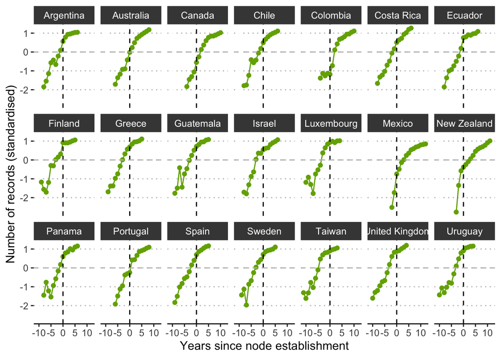

```r
trajectories_plot <- function(data_before_after, variable_name) {

  labels <- c(n_records_years = "Number of records (standardised)",
              n_users_years = "Number of users (standardised)",
              n_species_years = "Number of species (standardised)",
              p_research_grade_years = "Proportion of research grade records (standardised)",
              n_literature_years = "Number of publications (standardised)")

  # plot
  ggplot(data_before_after,
         aes(x = years_since_node, y = !!sym(variable_name))) +
    geom_line(col='#74AC00') +
    geom_point(col='#74AC00') +
    geom_vline(xintercept = 0, linetype = "dashed", color = "black") +
    geom_hline(yintercept = 0, linetype = "dashed", color = "grey") +
    facet_wrap(~ country_name, scales = "fixed", nrow = 3) +
    labs(x = "Years since node establishment", y = labels[[variable_name]]) +
    ggpubr::theme_pubclean() +
    theme(axis.line.x = element_line(size = 0.5),
          strip.background = element_rect(fill = "#454545"),
          strip.text = element_text(color = "white"))
}

trajectories_plot(data_before_after = data_before_after_records,
                  variable_name = 'n_records_years')
```

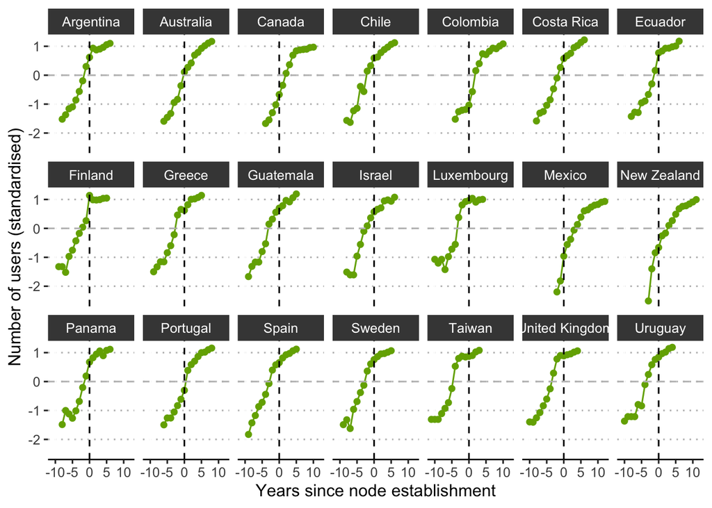

```r
trajectories_plot(data_before_after = data_before_after_users,
                  variable_name = 'n_users_years')
```

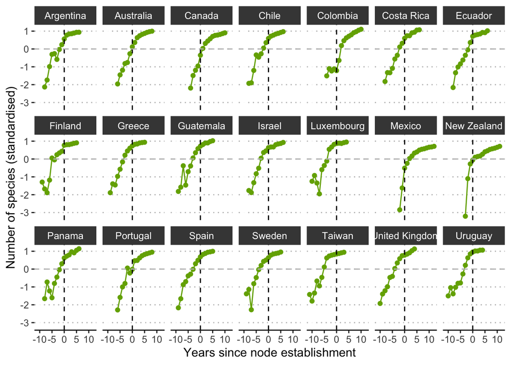

```r
trajectories_plot(data_before_after = data_before_after_species,
                  variable_name = 'n_species_years')
```

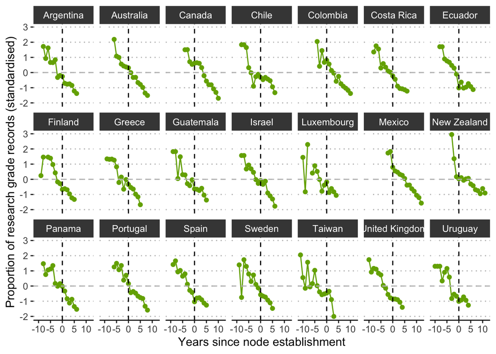

```r
trajectories_plot(data_before_after = data_before_after_p_research_grade,
                  variable_name = 'p_research_grade_years')
```

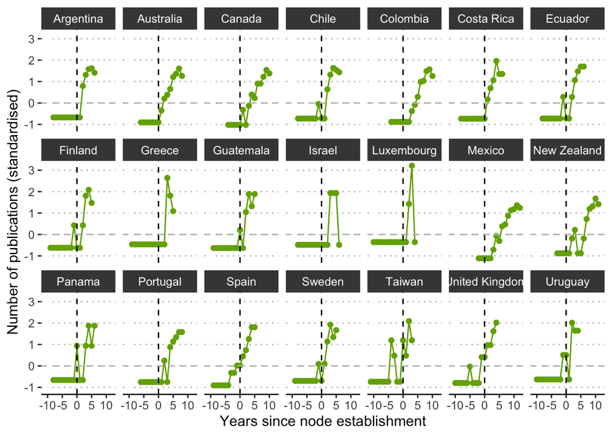

```r
trajectories_plot(data_before_after = data_before_after_literature,
                  variable_name = 'n_literature_years')
```

```r
# save 1000 x 600
```

## Test with all countries (not just the network members) using an arbitrary break-point

```r
break_point <- 2019

data_before_after_records_all <- data_temporal_records %>%
  select(country_name, node_name, year, n_records_years, has_node) %>%
  mutate(year_break_point = year - break_point,
         post_break = ifelse(year >= break_point, 1,0)) %>%
  mutate(n_records_years = scale(log10(n_records_years+1))[,1])


data_before_after_records_all %>%
  filter(country_name=='Uruguay') %>% knitr::kable(digits = 3)
```

| country_name | node_name | year | n_records_years | has_node | year_break_point | post_break |
| --- | --- | --- | --- | --- | --- | --- |
| Uruguay | NaturalistaUY | 2011 | -1.456 | 1 | -8 | 0 |
| Uruguay | NaturalistaUY | 2012 | -1.116 | 1 | -7 | 0 |
| Uruguay | NaturalistaUY | 2013 | -1.346 | 1 | -6 | 0 |
| Uruguay | NaturalistaUY | 2014 | -1.080 | 1 | -5 | 0 |
| Uruguay | NaturalistaUY | 2015 | -0.850 | 1 | -4 | 0 |
| Uruguay | NaturalistaUY | 2016 | -0.881 | 1 | -3 | 0 |
| Uruguay | NaturalistaUY | 2017 | -0.426 | 1 | -2 | 0 |
| Uruguay | NaturalistaUY | 2018 | -0.040 | 1 | -1 | 0 |
| Uruguay | NaturalistaUY | 2019 | 0.311 | 1 | 0 | 1 |
| Uruguay | NaturalistaUY | 2020 | 0.604 | 1 | 1 | 1 |
| Uruguay | NaturalistaUY | 2021 | 0.707 | 1 | 2 | 1 |
| Uruguay | NaturalistaUY | 2022 | 0.845 | 1 | 3 | 1 |
| Uruguay | NaturalistaUY | 2023 | 0.883 | 1 | 4 | 1 |
| Uruguay | NaturalistaUY | 2024 | 0.926 | 1 | 5 | 1 |
| Uruguay | NaturalistaUY | 2025 | 0.935 | 1 | 6 | 1 |

```r
n_records_before_after_all <- lmer(n_records_years ~ has_node * year_break_point * post_break +
                                 (1 + year_break_point | country_name),
                               data = data_before_after_records_all)

summary(n_records_before_after_all)$call
```

```
lmer(formula = n_records_years ~ has_node * year_break_point *
    post_break + (1 + year_break_point | country_name), data = data_before_after_records_all)
```

```r
performance::performance(n_records_before_after_all)
```

```
# Indices of model performance

AIC   |  AICc |   BIC | R2 (cond.) | R2 (marg.) |   ICC |  RMSE | Sigma
-----------------------------------------------------------------------
850.4 | 850.5 | 918.0 |      0.943 |      0.682 | 0.821 | 0.223 | 0.239
```

```r
tab_model(n_records_before_after_all)
```

[output not shown]

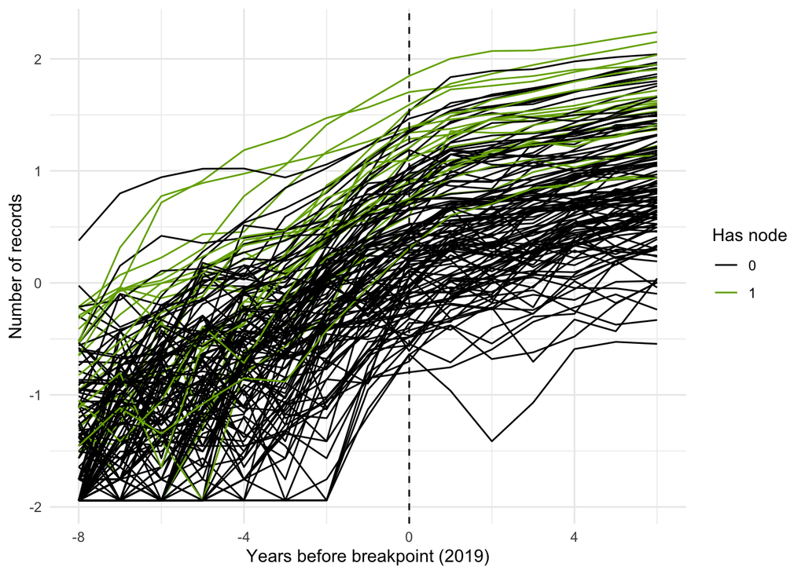

```r
pred <- ggpredict(n_records_before_after_all, terms = c("year_break_point", "post_break", "has_node"))

ggplot(data_before_after_records_all,
       aes(x = year_break_point, y = n_records_years, group = country_name)) +
  geom_line(alpha = 1, aes(col = as.factor(has_node))) +
  scale_color_manual(values = c('black','#74AC00')) +
  # geom_line(data = pred, aes(x = x, y = predicted),
  #           linewidth = 1, inherit.aes = FALSE, color='red') +
  geom_vline(xintercept = 0, linetype = "dashed") +
  labs(x = "Years before breakpoint (2019)", y = "Number of records", col='Has node') +
  theme_minimal()
```